# wrangle_act

### Introduction

Data wrangling is a core skill that everyone who works with data should be familiar with since so much of the world's data isn't clean. The repurcussions of ignoring data wrangling before analysis can be so bad and sometimes unimaginable. If we analyze, visualize, or model our data before we wrangle it, our consequences could be making mistakes, missing out on cool insights, and wasting time. So best practices say wrangle. Always.

In this project, we gather data from various sources and in variety of forms. When data is sourced from different sources, there are extreme inconsistencies between them. So inorder to analyse this data, cleaning must be considered first.

The dataset that we will be wrangling (and analyzing and visualizing) is the tweet archive of Twitter user @dog_rates, also known as WeRateDogs.

[figure not shown]

```python
# import libraries

import pandas as pd
import requests
import time
import json
import tweepy
import os
import matplotlib.pyplot as plt
import numpy as np
import seaborn as sns
import tweepy
```

### Gather Data

#### Gather data 1 - From the twitter-archive-enhanced.csv file

```python
# load tweets archieve data
tweets_df = pd.read_csv('twitter-archive-enhanced.csv')
tweets_df.head()
```

|  | tweet_id | in_reply_to_status_id | in_reply_to_user_id | timestamp | source | text | retweeted_status_id | retweeted_status_user_id | retweeted_status_timestamp | expanded_urls | rating_numerator | rating_denominator | name | doggo | floofer | pupper | puppo |
| --- | --- | --- | --- | --- | --- | --- | --- | --- | --- | --- | --- | --- | --- | --- | --- | --- | --- |
| 0 | 892420643555336193 | NaN | NaN | 2017-08-01 16:23:56 +0000 | <a href="http://twitter.com/download/iphone" rel="nofollow">Twitter for iPhone</a> | This is Phineas. He's a mystical boy. Only ever appears in the hole of a donut. 13/10 https://t.co/MgUWQ76dJU | NaN | NaN | NaN | https://twitter.com/dog_rates/status/892420643555336193/photo/1 | 13 | 10 | Phineas | None | None | None | None |
| 1 | 892177421306343426 | NaN | NaN | 2017-08-01 00:17:27 +0000 | <a href="http://twitter.com/download/iphone" rel="nofollow">Twitter for iPhone</a> | This is Tilly. She's just checking pup on you. Hopes you're doing ok. If not, she's available for pats, snugs, boops, the whole bit. 13/10 https://t.co/0Xxu71qeIV | NaN | NaN | NaN | https://twitter.com/dog_rates/status/892177421306343426/photo/1 | 13 | 10 | Tilly | None | None | None | None |
| 2 | 891815181378084864 | NaN | NaN | 2017-07-31 00:18:03 +0000 | <a href="http://twitter.com/download/iphone" rel="nofollow">Twitter for iPhone</a> | This is Archie. He is a rare Norwegian Pouncing Corgo. Lives in the tall grass. You never know when one may strike. 12/10 https://t.co/wUnZnhtVJB | NaN | NaN | NaN | https://twitter.com/dog_rates/status/891815181378084864/photo/1 | 12 | 10 | Archie | None | None | None | None |
| 3 | 891689557279858688 | NaN | NaN | 2017-07-30 15:58:51 +0000 | <a href="http://twitter.com/download/iphone" rel="nofollow">Twitter for iPhone</a> | This is Darla. She commenced a snooze mid meal. 13/10 happens to the best of us https://t.co/tD36da7qLQ | NaN | NaN | NaN | https://twitter.com/dog_rates/status/891689557279858688/photo/1 | 13 | 10 | Darla | None | None | None | None |
| 4 | 891327558926688256 | NaN | NaN | 2017-07-29 16:00:24 +0000 | <a href="http://twitter.com/download/iphone" rel="nofollow">Twitter for iPhone</a> | This is Franklin. He would like you to stop calling him "cute." He is a very fierce shark and should be respected as such. 12/10 #BarkWeek https://t.co/AtUZn91f7f | NaN | NaN | NaN | https://twitter.com/dog_rates/status/891327558926688256/photo/1,https://twitter.com/dog_rates/status/891327558926688256/photo/1 | 12 | 10 | Franklin | None | None | None | None |

#### Gather data 2 - Get data from the url using requests library

```python
# get image preictions data

#url = 'https://d17h27t6h515a5.cloudfront.net/topher/2017/August/599fd2ad_image-predictions/image-predictions.tsv'
#response = requests.get(url)
#with open(os.path.join('./', url.split('/')[-1]), mode='wb') as file:
#file.write(response.content)
```

```python
# load image predictions data

images_df = pd.read_csv('image-predictions.tsv', sep='\t')
images_df.head()
```

|  | tweet_id | jpg_url | img_num | p1 | p1_conf | p1_dog | p2 | p2_conf | p2_dog | p3 | p3_conf | p3_dog |
| --- | --- | --- | --- | --- | --- | --- | --- | --- | --- | --- | --- | --- |
| 0 | 666020888022790149 | https://pbs.twimg.com/media/CT4udn0WwAA0aMy.jpg | 1 | Welsh_springer_spaniel | 0.465074 | True | collie | 0.156665 | True | Shetland_sheepdog | 0.061428 | True |
| 1 | 666029285002620928 | https://pbs.twimg.com/media/CT42GRgUYAA5iDo.jpg | 1 | redbone | 0.506826 | True | miniature_pinscher | 0.074192 | True | Rhodesian_ridgeback | 0.072010 | True |
| 2 | 666033412701032449 | https://pbs.twimg.com/media/CT4521TWwAEvMyu.jpg | 1 | German_shepherd | 0.596461 | True | malinois | 0.138584 | True | bloodhound | 0.116197 | True |
| 3 | 666044226329800704 | https://pbs.twimg.com/media/CT5Dr8HUEAA-lEu.jpg | 1 | Rhodesian_ridgeback | 0.408143 | True | redbone | 0.360687 | True | miniature_pinscher | 0.222752 | True |
| 4 | 666049248165822465 | https://pbs.twimg.com/media/CT5IQmsXIAAKY4A.jpg | 1 | miniature_pinscher | 0.560311 | True | Rottweiler | 0.243682 | True | Doberman | 0.154629 | True |

#### Gather data 3 - More info from WeRateDogs using Twitter API

```python
#consumer_key = ''
#consumer_secret = ''
#access_token = ''
#access_secret = ''


#auth = tweepy.OAuthHandler(consumer_key, consumer_secret)
#auth.set_access_token(access_token, access_secret)

#api = tweepy.API(auth, wait_on_rate_limit= True,wait_on_rate_limit_notify= True)
```

```python
#append twitter status to file named tweet_json.txt
#with open('tweet_json.txt', 'a') as file:
 #   for tweet_id in tweets_df['tweet_id']:
 #       try:
 #           tweet = api.get_status(tweet_id,tweet_mode = 'extended')
 #           json.dump(tweet._json, file)
 #          file.write('\n')
  #     except:
  #         continue
```

```python
#append information of above file in list
#tweets_data = []
#for line in open('tweet_json.txt', 'r'):
#    try:
#        tweets_data.append(json.loads(line))
#    except:
#        continue
```

```python
# read tweet_json.txt and create an appropriate dataframe
df_list = []
with open('tweet_json.txt', 'r') as file:
    lines = file.read().splitlines()
    for line_data in lines:
        json_data = json.loads(line_data)
        tweet_id = json_data['id']
        favorite_count = json_data['favorite_count']
        retweet_count = json_data['retweet_count']
        df_list.append({
            'tweet_id': tweet_id,
            'favorite_count': favorite_count,
            'retweet_count': retweet_count
        })
likes_df = pd.DataFrame(df_list)
likes_df.head()
```

|  | favorite_count | retweet_count | tweet_id |
| --- | --- | --- | --- |
| 0 | 38167 | 8351 | 892420643555336193 |
| 1 | 32731 | 6171 | 892177421306343426 |
| 2 | 24640 | 4082 | 891815181378084864 |
| 3 | 41495 | 8496 | 891689557279858688 |
| 4 | 39675 | 9186 | 891327558926688256 |

### Assess Data

#### Visual Assessment

```python
tweets_df
```

|  | tweet_id | in_reply_to_status_id | in_reply_to_user_id | timestamp | source | text | retweeted_status_id | retweeted_status_user_id | retweeted_status_timestamp | expanded_urls | rating_numerator | rating_denominator | name | doggo | floofer | pupper | puppo |
| --- | --- | --- | --- | --- | --- | --- | --- | --- | --- | --- | --- | --- | --- | --- | --- | --- | --- |
| 0 | 892420643555336193 | NaN | NaN | 2017-08-01 16:23:56 +0000 | <a href="http://twitter.com/download/iphone" rel="nofollow">Twitter for iPhone</a> | This is Phineas. He's a mystical boy. Only ever appears in the hole of a donut. 13/10 https://t.co/MgUWQ76dJU | NaN | NaN | NaN | https://twitter.com/dog_rates/status/892420643555336193/photo/1 | 13 | 10 | Phineas | None | None | None | None |
| 1 | 892177421306343426 | NaN | NaN | 2017-08-01 00:17:27 +0000 | <a href="http://twitter.com/download/iphone" rel="nofollow">Twitter for iPhone</a> | This is Tilly. She's just checking pup on you. Hopes you're doing ok. If not, she's available for pats, snugs, boops, the whole bit. 13/10 https://t.co/0Xxu71qeIV | NaN | NaN | NaN | https://twitter.com/dog_rates/status/892177421306343426/photo/1 | 13 | 10 | Tilly | None | None | None | None |
| 2 | 891815181378084864 | NaN | NaN | 2017-07-31 00:18:03 +0000 | <a href="http://twitter.com/download/iphone" rel="nofollow">Twitter for iPhone</a> | This is Archie. He is a rare Norwegian Pouncing Corgo. Lives in the tall grass. You never know when one may strike. 12/10 https://t.co/wUnZnhtVJB | NaN | NaN | NaN | https://twitter.com/dog_rates/status/891815181378084864/photo/1 | 12 | 10 | Archie | None | None | None | None |
| 3 | 891689557279858688 | NaN | NaN | 2017-07-30 15:58:51 +0000 | <a href="http://twitter.com/download/iphone" rel="nofollow">Twitter for iPhone</a> | This is Darla. She commenced a snooze mid meal. 13/10 happens to the best of us https://t.co/tD36da7qLQ | NaN | NaN | NaN | https://twitter.com/dog_rates/status/891689557279858688/photo/1 | 13 | 10 | Darla | None | None | None | None |
| 4 | 891327558926688256 | NaN | NaN | 2017-07-29 16:00:24 +0000 | <a href="http://twitter.com/download/iphone" rel="nofollow">Twitter for iPhone</a> | This is Franklin. He would like you to stop calling him "cute." He is a very fierce shark and should be respected as such. 12/10 #BarkWeek https://t.co/AtUZn91f7f | NaN | NaN | NaN | https://twitter.com/dog_rates/status/891327558926688256/photo/1,https://twitter.com/dog_rates/status/891327558926688256/photo/1 | 12 | 10 | Franklin | None | None | None | None |
| 5 | 891087950875897856 | NaN | NaN | 2017-07-29 00:08:17 +0000 | <a href="http://twitter.com/download/iphone" rel="nofollow">Twitter for iPhone</a> | Here we have a majestic great white breaching off South Africa's coast. Absolutely h*ckin breathtaking. 13/10 (IG: tucker_marlo) #BarkWeek https://t.co/kQ04fDDRmh | NaN | NaN | NaN | https://twitter.com/dog_rates/status/891087950875897856/photo/1 | 13 | 10 | None | None | None | None | None |
| 6 | 890971913173991426 | NaN | NaN | 2017-07-28 16:27:12 +0000 | <a href="http://twitter.com/download/iphone" rel="nofollow">Twitter for iPhone</a> | Meet Jax. He enjoys ice cream so much he gets nervous around it. 13/10 help Jax enjoy more things by clicking below\n\nhttps://t.co/Zr4hWfAs1H https://t.co/tVJBRMnhxl | NaN | NaN | NaN | https://gofundme.com/ydvmve-surgery-for-jax,https://twitter.com/dog_rates/status/890971913173991426/photo/1 | 13 | 10 | Jax | None | None | None | None |
| 7 | 890729181411237888 | NaN | NaN | 2017-07-28 00:22:40 +0000 | <a href="http://twitter.com/download/iphone" rel="nofollow">Twitter for iPhone</a> | When you watch your owner call another dog a good boy but then they turn back to you and say you're a great boy. 13/10 https://t.co/v0nONBcwxq | NaN | NaN | NaN | https://twitter.com/dog_rates/status/890729181411237888/photo/1,https://twitter.com/dog_rates/status/890729181411237888/photo/1 | 13 | 10 | None | None | None | None | None |
| 8 | 890609185150312448 | NaN | NaN | 2017-07-27 16:25:51 +0000 | <a href="http://twitter.com/download/iphone" rel="nofollow">Twitter for iPhone</a> | This is Zoey. She doesn't want to be one of the scary sharks. Just wants to be a snuggly pettable boatpet. 13/10 #BarkWeek https://t.co/9TwLuAGH0b | NaN | NaN | NaN | https://twitter.com/dog_rates/status/890609185150312448/photo/1 | 13 | 10 | Zoey | None | None | None | None |
| 9 | 890240255349198849 | NaN | NaN | 2017-07-26 15:59:51 +0000 | <a href="http://twitter.com/download/iphone" rel="nofollow">Twitter for iPhone</a> | This is Cassie. She is a college pup. Studying international doggo communication and stick theory. 14/10 so elegant much sophisticate https://t.co/t1bfwz5S2A | NaN | NaN | NaN | https://twitter.com/dog_rates/status/890240255349198849/photo/1 | 14 | 10 | Cassie | doggo | None | None | None |
| 10 | 890006608113172480 | NaN | NaN | 2017-07-26 00:31:25 +0000 | <a href="http://twitter.com/download/iphone" rel="nofollow">Twitter for iPhone</a> | This is Koda. He is a South Australian deckshark. Deceptively deadly. Frighteningly majestic. 13/10 would risk a petting #BarkWeek https://t.co/dVPW0B0Mme | NaN | NaN | NaN | https://twitter.com/dog_rates/status/890006608113172480/photo/1,https://twitter.com/dog_rates/status/890006608113172480/photo/1 | 13 | 10 | Koda | None | None | None | None |
| 11 | 889880896479866881 | NaN | NaN | 2017-07-25 16:11:53 +0000 | <a href="http://twitter.com/download/iphone" rel="nofollow">Twitter for iPhone</a> | This is Bruno. He is a service shark. Only gets out of the water to assist you. 13/10 terrifyingly good boy https://t.co/u1XPQMl29g | NaN | NaN | NaN | https://twitter.com/dog_rates/status/889880896479866881/photo/1 | 13 | 10 | Bruno | None | None | None | None |
| 12 | 889665388333682689 | NaN | NaN | 2017-07-25 01:55:32 +0000 | <a href="http://twitter.com/download/iphone" rel="nofollow">Twitter for iPhone</a> | Here's a puppo that seems to be on the fence about something haha no but seriously someone help her. 13/10 https://t.co/BxvuXk0UCm | NaN | NaN | NaN | https://twitter.com/dog_rates/status/889665388333682689/photo/1 | 13 | 10 | None | None | None | None | puppo |
| 13 | 889638837579907072 | NaN | NaN | 2017-07-25 00:10:02 +0000 | <a href="http://twitter.com/download/iphone" rel="nofollow">Twitter for iPhone</a> | This is Ted. He does his best. Sometimes that's not enough. But it's ok. 12/10 would assist https://t.co/f8dEDcrKSR | NaN | NaN | NaN | https://twitter.com/dog_rates/status/889638837579907072/photo/1,https://twitter.com/dog_rates/status/889638837579907072/photo/1 | 12 | 10 | Ted | None | None | None | None |
| 14 | 889531135344209921 | NaN | NaN | 2017-07-24 17:02:04 +0000 | <a href="http://twitter.com/download/iphone" rel="nofollow">Twitter for iPhone</a> | This is Stuart. He's sporting his favorite fanny pack. Secretly filled with bones only. 13/10 puppared puppo #BarkWeek https://t.co/y70o6h3isq | NaN | NaN | NaN | https://twitter.com/dog_rates/status/889531135344209921/photo/1 | 13 | 10 | Stuart | None | None | None | puppo |
| 15 | 889278841981685760 | NaN | NaN | 2017-07-24 00:19:32 +0000 | <a href="http://twitter.com/download/iphone" rel="nofollow">Twitter for iPhone</a> | This is Oliver. You're witnessing one of his many brutal attacks. Seems to be playing with his victim. 13/10 fr*ckin frightening #BarkWeek https://t.co/WpHvrQedPb | NaN | NaN | NaN | https://twitter.com/dog_rates/status/889278841981685760/video/1 | 13 | 10 | Oliver | None | None | None | None |
| 16 | 888917238123831296 | NaN | NaN | 2017-07-23 00:22:39 +0000 | <a href="http://twitter.com/download/iphone" rel="nofollow">Twitter for iPhone</a> | This is Jim. He found a fren. Taught him how to sit like the good boys. 12/10 for both https://t.co/chxruIOUJN | NaN | NaN | NaN | https://twitter.com/dog_rates/status/888917238123831296/photo/1 | 12 | 10 | Jim | None | None | None | None |
| 17 | 888804989199671297 | NaN | NaN | 2017-07-22 16:56:37 +0000 | <a href="http://twitter.com/download/iphone" rel="nofollow">Twitter for iPhone</a> | This is Zeke. He has a new stick. Very proud of it. Would like you to throw it for him without taking it. 13/10 would do my best https://t.co/HTQ77yNQ5K | NaN | NaN | NaN | https://twitter.com/dog_rates/status/888804989199671297/photo/1,https://twitter.com/dog_rates/status/888804989199671297/photo/1 | 13 | 10 | Zeke | None | None | None | None |
| 18 | 888554962724278272 | NaN | NaN | 2017-07-22 00:23:06 +0000 | <a href="http://twitter.com/download/iphone" rel="nofollow">Twitter for iPhone</a> | This is Ralphus. He's powering up. Attempting maximum borkdrive. 13/10 inspirational af https://t.co/YnYAFCTTiK | NaN | NaN | NaN | https://twitter.com/dog_rates/status/888554962724278272/photo/1,https://twitter.com/dog_rates/status/888554962724278272/photo/1,https://twitter.com/dog_rates/status/888554962724278272/photo/1,https://… | 13 | 10 | Ralphus | None | None | None | None |
| 19 | 888202515573088257 | NaN | NaN | 2017-07-21 01:02:36 +0000 | <a href="http://twitter.com/download/iphone" rel="nofollow">Twitter for iPhone</a> | RT @dog_rates: This is Canela. She attempted some fancy porch pics. They were unsuccessful. 13/10 someone help her https://t.co/cLyzpcUcMX | 8.874740e+17 | 4.196984e+09 | 2017-07-19 00:47:34 +0000 | https://twitter.com/dog_rates/status/887473957103951883/photo/1,https://twitter.com/dog_rates/status/887473957103951883/photo/1,https://twitter.com/dog_rates/status/887473957103951883/photo/1,https://… | 13 | 10 | Canela | None | None | None | None |
| 20 | 888078434458587136 | NaN | NaN | 2017-07-20 16:49:33 +0000 | <a href="http://twitter.com/download/iphone" rel="nofollow">Twitter for iPhone</a> | This is Gerald. He was just told he didn't get the job he interviewed for. A h*ckin injustice. 12/10 didn't want the job anyway https://t.co/DK7iDPfuRX | NaN | NaN | NaN | https://twitter.com/dog_rates/status/888078434458587136/photo/1,https://twitter.com/dog_rates/status/888078434458587136/photo/1 | 12 | 10 | Gerald | None | None | None | None |
| 21 | 887705289381826560 | NaN | NaN | 2017-07-19 16:06:48 +0000 | <a href="http://twitter.com/download/iphone" rel="nofollow">Twitter for iPhone</a> | This is Jeffrey. He has a monopoly on the pool noodles. Currently running a 'boop for two' midweek sale. 13/10 h*ckin strategic https://t.co/PhrUk20Q64 | NaN | NaN | NaN | https://twitter.com/dog_rates/status/887705289381826560/photo/1 | 13 | 10 | Jeffrey | None | None | None | None |
| 22 | 887517139158093824 | NaN | NaN | 2017-07-19 03:39:09 +0000 | <a href="http://twitter.com/download/iphone" rel="nofollow">Twitter for iPhone</a> | I've yet to rate a Venezuelan Hover Wiener. This is such an honor. 14/10 paw-inspiring af (IG: roxy.thedoxy) https://t.co/20VrLAA8ba | NaN | NaN | NaN | https://twitter.com/dog_rates/status/887517139158093824/video/1 | 14 | 10 | such | None | None | None | None |
| 23 | 887473957103951883 | NaN | NaN | 2017-07-19 00:47:34 +0000 | <a href="http://twitter.com/download/iphone" rel="nofollow">Twitter for iPhone</a> | This is Canela. She attempted some fancy porch pics. They were unsuccessful. 13/10 someone help her https://t.co/cLyzpcUcMX | NaN | NaN | NaN | https://twitter.com/dog_rates/status/887473957103951883/photo/1,https://twitter.com/dog_rates/status/887473957103951883/photo/1 | 13 | 10 | Canela | None | None | None | None |
| 24 | 887343217045368832 | NaN | NaN | 2017-07-18 16:08:03 +0000 | <a href="http://twitter.com/download/iphone" rel="nofollow">Twitter for iPhone</a> | You may not have known you needed to see this today. 13/10 please enjoy (IG: emmylouroo) https://t.co/WZqNqygEyV | NaN | NaN | NaN | https://twitter.com/dog_rates/status/887343217045368832/video/1 | 13 | 10 | None | None | None | None | None |
| 25 | 887101392804085760 | NaN | NaN | 2017-07-18 00:07:08 +0000 | <a href="http://twitter.com/download/iphone" rel="nofollow">Twitter for iPhone</a> | This... is a Jubilant Antarctic House Bear. We only rate dogs. Please only send dogs. Thank you... 12/10 would suffocate in floof https://t.co/4Ad1jzJSdp | NaN | NaN | NaN | https://twitter.com/dog_rates/status/887101392804085760/photo/1 | 12 | 10 | None | None | None | None | None |
| 26 | 886983233522544640 | NaN | NaN | 2017-07-17 16:17:36 +0000 | <a href="http://twitter.com/download/iphone" rel="nofollow">Twitter for iPhone</a> | This is Maya. She's very shy. Rarely leaves her cup. 13/10 would find her an environment to thrive in https://t.co/I6oNy0CgiT | NaN | NaN | NaN | https://twitter.com/dog_rates/status/886983233522544640/photo/1,https://twitter.com/dog_rates/status/886983233522544640/photo/1 | 13 | 10 | Maya | None | None | None | None |
| 27 | 886736880519319552 | NaN | NaN | 2017-07-16 23:58:41 +0000 | <a href="http://twitter.com/download/iphone" rel="nofollow">Twitter for iPhone</a> | This is Mingus. He's a wonderful father to his smol pup. Confirmed 13/10, but he needs your help\n\nhttps://t.co/bVi0Yr4Cff https://t.co/ISvKOSkd5b | NaN | NaN | NaN | https://www.gofundme.com/mingusneedsus,https://twitter.com/dog_rates/status/886736880519319552/photo/1,https://twitter.com/dog_rates/status/886736880519319552/photo/1 | 13 | 10 | Mingus | None | None | None | None |
| 28 | 886680336477933568 | NaN | NaN | 2017-07-16 20:14:00 +0000 | <a href="http://twitter.com/download/iphone" rel="nofollow">Twitter for iPhone</a> | This is Derek. He's late for a dog meeting. 13/10 pet...al to the metal https://t.co/BCoWue0abA | NaN | NaN | NaN | https://twitter.com/dog_rates/status/886680336477933568/photo/1 | 13 | 10 | Derek | None | None | None | None |
| 29 | 886366144734445568 | NaN | NaN | 2017-07-15 23:25:31 +0000 | <a href="http://twitter.com/download/iphone" rel="nofollow">Twitter for iPhone</a> | This is Roscoe. Another pupper fallen victim to spontaneous tongue ejections. Get the BlepiPen immediate. 12/10 deep breaths Roscoe https://t.co/RGE08MIJox | NaN | NaN | NaN | https://twitter.com/dog_rates/status/886366144734445568/photo/1,https://twitter.com/dog_rates/status/886366144734445568/photo/1 | 12 | 10 | Roscoe | None | None | pupper | None |
| ... | ... | ... | ... | ... | ... | ... | ... | ... | ... | ... | ... | ... | ... | ... | ... | ... | ... |
| 2326 | 666411507551481857 | NaN | NaN | 2015-11-17 00:24:19 +0000 | <a href="http://twitter.com/download/iphone" rel="nofollow">Twitter for iPhone</a> | This is quite the dog. Gets really excited when not in water. Not very soft tho. Bad at fetch. Can't do tricks. 2/10 https://t.co/aMCTNWO94t | NaN | NaN | NaN | https://twitter.com/dog_rates/status/666411507551481857/photo/1 | 2 | 10 | quite | None | None | None | None |
| 2327 | 666407126856765440 | NaN | NaN | 2015-11-17 00:06:54 +0000 | <a href="http://twitter.com/download/iphone" rel="nofollow">Twitter for iPhone</a> | This is a southern Vesuvius bumblegruff. Can drive a truck (wow). Made friends with 5 other nifty dogs (neat). 7/10 https://t.co/LopTBkKa8h | NaN | NaN | NaN | https://twitter.com/dog_rates/status/666407126856765440/photo/1 | 7 | 10 | a | None | None | None | None |
| 2328 | 666396247373291520 | NaN | NaN | 2015-11-16 23:23:41 +0000 | <a href="http://twitter.com/download/iphone" rel="nofollow">Twitter for iPhone</a> | Oh goodness. A super rare northeast Qdoba kangaroo mix. Massive feet. No pouch (disappointing). Seems alert. 9/10 https://t.co/Dc7b0E8qFE | NaN | NaN | NaN | https://twitter.com/dog_rates/status/666396247373291520/photo/1 | 9 | 10 | None | None | None | None | None |
| 2329 | 666373753744588802 | NaN | NaN | 2015-11-16 21:54:18 +0000 | <a href="http://twitter.com/download/iphone" rel="nofollow">Twitter for iPhone</a> | Those are sunglasses and a jean jacket. 11/10 dog cool af https://t.co/uHXrPkUEyl | NaN | NaN | NaN | https://twitter.com/dog_rates/status/666373753744588802/photo/1 | 11 | 10 | None | None | None | None | None |
| 2330 | 666362758909284353 | NaN | NaN | 2015-11-16 21:10:36 +0000 | <a href="http://twitter.com/download/iphone" rel="nofollow">Twitter for iPhone</a> | Unique dog here. Very small. Lives in container of Frosted Flakes (?). Short legs. Must be rare 6/10 would still pet https://t.co/XMD9CwjEnM | NaN | NaN | NaN | https://twitter.com/dog_rates/status/666362758909284353/photo/1 | 6 | 10 | None | None | None | None | None |
| 2331 | 666353288456101888 | NaN | NaN | 2015-11-16 20:32:58 +0000 | <a href="http://twitter.com/download/iphone" rel="nofollow">Twitter for iPhone</a> | Here we have a mixed Asiago from the Galápagos Islands. Only one ear working. Big fan of marijuana carpet. 8/10 https://t.co/tltQ5w9aUO | NaN | NaN | NaN | https://twitter.com/dog_rates/status/666353288456101888/photo/1 | 8 | 10 | None | None | None | None | None |
| 2332 | 666345417576210432 | NaN | NaN | 2015-11-16 20:01:42 +0000 | <a href="http://twitter.com/download/iphone" rel="nofollow">Twitter for iPhone</a> | Look at this jokester thinking seat belt laws don't apply to him. Great tongue tho 10/10 https://t.co/VFKG1vxGjB | NaN | NaN | NaN | https://twitter.com/dog_rates/status/666345417576210432/photo/1 | 10 | 10 | None | None | None | None | None |
| 2333 | 666337882303524864 | NaN | NaN | 2015-11-16 19:31:45 +0000 | <a href="http://twitter.com/download/iphone" rel="nofollow">Twitter for iPhone</a> | This is an extremely rare horned Parthenon. Not amused. Wears shoes. Overall very nice. 9/10 would pet aggressively https://t.co/QpRjllzWAL | NaN | NaN | NaN | https://twitter.com/dog_rates/status/666337882303524864/photo/1 | 9 | 10 | an | None | None | None | None |
| 2334 | 666293911632134144 | NaN | NaN | 2015-11-16 16:37:02 +0000 | <a href="http://twitter.com/download/iphone" rel="nofollow">Twitter for iPhone</a> | This is a funny dog. Weird toes. Won't come down. Loves branch. Refuses to eat his food. Hard to cuddle with. 3/10 https://t.co/IIXis0zta0 | NaN | NaN | NaN | https://twitter.com/dog_rates/status/666293911632134144/photo/1 | 3 | 10 | a | None | None | None | None |
| 2335 | 666287406224695296 | NaN | NaN | 2015-11-16 16:11:11 +0000 | <a href="http://twitter.com/download/iphone" rel="nofollow">Twitter for iPhone</a> | This is an Albanian 3 1/2 legged Episcopalian. Loves well-polished hardwood flooring. Penis on the collar. 9/10 https://t.co/d9NcXFKwLv | NaN | NaN | NaN | https://twitter.com/dog_rates/status/666287406224695296/photo/1 | 1 | 2 | an | None | None | None | None |
| 2336 | 666273097616637952 | NaN | NaN | 2015-11-16 15:14:19 +0000 | <a href="http://twitter.com/download/iphone" rel="nofollow">Twitter for iPhone</a> | Can take selfies 11/10 https://t.co/ws2AMaNwPW | NaN | NaN | NaN | https://twitter.com/dog_rates/status/666273097616637952/photo/1 | 11 | 10 | None | None | None | None | None |
| 2337 | 666268910803644416 | NaN | NaN | 2015-11-16 14:57:41 +0000 | <a href="http://twitter.com/download/iphone" rel="nofollow">Twitter for iPhone</a> | Very concerned about fellow dog trapped in computer. 10/10 https://t.co/0yxApIikpk | NaN | NaN | NaN | https://twitter.com/dog_rates/status/666268910803644416/photo/1 | 10 | 10 | None | None | None | None | None |
| 2338 | 666104133288665088 | NaN | NaN | 2015-11-16 04:02:55 +0000 | <a href="http://twitter.com/download/iphone" rel="nofollow">Twitter for iPhone</a> | Not familiar with this breed. No tail (weird). Only 2 legs. Doesn't bark. Surprisingly quick. Shits eggs. 1/10 https://t.co/Asgdc6kuLX | NaN | NaN | NaN | https://twitter.com/dog_rates/status/666104133288665088/photo/1 | 1 | 10 | None | None | None | None | None |
| 2339 | 666102155909144576 | NaN | NaN | 2015-11-16 03:55:04 +0000 | <a href="http://twitter.com/download/iphone" rel="nofollow">Twitter for iPhone</a> | Oh my. Here you are seeing an Adobe Setter giving birth to twins!!! The world is an amazing place. 11/10 https://t.co/11LvqN4WLq | NaN | NaN | NaN | https://twitter.com/dog_rates/status/666102155909144576/photo/1 | 11 | 10 | None | None | None | None | None |
| 2340 | 666099513787052032 | NaN | NaN | 2015-11-16 03:44:34 +0000 | <a href="http://twitter.com/download/iphone" rel="nofollow">Twitter for iPhone</a> | Can stand on stump for what seems like a while. Built that birdhouse? Impressive. Made friends with a squirrel. 8/10 https://t.co/Ri4nMTLq5C | NaN | NaN | NaN | https://twitter.com/dog_rates/status/666099513787052032/photo/1 | 8 | 10 | None | None | None | None | None |
| 2341 | 666094000022159362 | NaN | NaN | 2015-11-16 03:22:39 +0000 | <a href="http://twitter.com/download/iphone" rel="nofollow">Twitter for iPhone</a> | This appears to be a Mongolian Presbyterian mix. Very tired. Tongue slip confirmed. 9/10 would lie down with https://t.co/mnioXo3IfP | NaN | NaN | NaN | https://twitter.com/dog_rates/status/666094000022159362/photo/1 | 9 | 10 | None | None | None | None | None |
| 2342 | 666082916733198337 | NaN | NaN | 2015-11-16 02:38:37 +0000 | <a href="http://twitter.com/download/iphone" rel="nofollow">Twitter for iPhone</a> | Here we have a well-established sunblockerspaniel. Lost his other flip-flop. 6/10 not very waterproof https://t.co/3RU6x0vHB7 | NaN | NaN | NaN | https://twitter.com/dog_rates/status/666082916733198337/photo/1 | 6 | 10 | None | None | None | None | None |
| 2343 | 666073100786774016 | NaN | NaN | 2015-11-16 01:59:36 +0000 | <a href="http://twitter.com/download/iphone" rel="nofollow">Twitter for iPhone</a> | Let's hope this flight isn't Malaysian (lol). What a dog! Almost completely camouflaged. 10/10 I trust this pilot https://t.co/Yk6GHE9tOY | NaN | NaN | NaN | https://twitter.com/dog_rates/status/666073100786774016/photo/1 | 10 | 10 | None | None | None | None | None |
| 2344 | 666071193221509120 | NaN | NaN | 2015-11-16 01:52:02 +0000 | <a href="http://twitter.com/download/iphone" rel="nofollow">Twitter for iPhone</a> | Here we have a northern speckled Rhododendron. Much sass. Gives 0 fucks. Good tongue. 9/10 would caress sensually https://t.co/ZoL8kq2XFx | NaN | NaN | NaN | https://twitter.com/dog_rates/status/666071193221509120/photo/1 | 9 | 10 | None | None | None | None | None |
| 2345 | 666063827256086533 | NaN | NaN | 2015-11-16 01:22:45 +0000 | <a href="http://twitter.com/download/iphone" rel="nofollow">Twitter for iPhone</a> | This is the happiest dog you will ever see. Very committed owner. Nice couch. 10/10 https://t.co/RhUEAloehK | NaN | NaN | NaN | https://twitter.com/dog_rates/status/666063827256086533/photo/1 | 10 | 10 | the | None | None | None | None |
| 2346 | 666058600524156928 | NaN | NaN | 2015-11-16 01:01:59 +0000 | <a href="http://twitter.com/download/iphone" rel="nofollow">Twitter for iPhone</a> | Here is the Rand Paul of retrievers folks! He's probably good at poker. Can drink beer (lol rad). 8/10 good dog https://t.co/pYAJkAe76p | NaN | NaN | NaN | https://twitter.com/dog_rates/status/666058600524156928/photo/1 | 8 | 10 | the | None | None | None | None |
| 2347 | 666057090499244032 | NaN | NaN | 2015-11-16 00:55:59 +0000 | <a href="http://twitter.com/download/iphone" rel="nofollow">Twitter for iPhone</a> | My oh my. This is a rare blond Canadian terrier on wheels. Only $8.98. Rather docile. 9/10 very rare https://t.co/yWBqbrzy8O | NaN | NaN | NaN | https://twitter.com/dog_rates/status/666057090499244032/photo/1 | 9 | 10 | a | None | None | None | None |
| 2348 | 666055525042405380 | NaN | NaN | 2015-11-16 00:49:46 +0000 | <a href="http://twitter.com/download/iphone" rel="nofollow">Twitter for iPhone</a> | Here is a Siberian heavily armored polar bear mix. Strong owner. 10/10 I would do unspeakable things to pet this dog https://t.co/rdivxLiqEt | NaN | NaN | NaN | https://twitter.com/dog_rates/status/666055525042405380/photo/1 | 10 | 10 | a | None | None | None | None |
| 2349 | 666051853826850816 | NaN | NaN | 2015-11-16 00:35:11 +0000 | <a href="http://twitter.com/download/iphone" rel="nofollow">Twitter for iPhone</a> | This is an odd dog. Hard on the outside but loving on the inside. Petting still fun. Doesn't play catch well. 2/10 https://t.co/v5A4vzSDdc | NaN | NaN | NaN | https://twitter.com/dog_rates/status/666051853826850816/photo/1 | 2 | 10 | an | None | None | None | None |
| 2350 | 666050758794694657 | NaN | NaN | 2015-11-16 00:30:50 +0000 | <a href="http://twitter.com/download/iphone" rel="nofollow">Twitter for iPhone</a> | This is a truly beautiful English Wilson Staff retriever. Has a nice phone. Privileged. 10/10 would trade lives with https://t.co/fvIbQfHjIe | NaN | NaN | NaN | https://twitter.com/dog_rates/status/666050758794694657/photo/1 | 10 | 10 | a | None | None | None | None |
| 2351 | 666049248165822465 | NaN | NaN | 2015-11-16 00:24:50 +0000 | <a href="http://twitter.com/download/iphone" rel="nofollow">Twitter for iPhone</a> | Here we have a 1949 1st generation vulpix. Enjoys sweat tea and Fox News. Cannot be phased. 5/10 https://t.co/4B7cOc1EDq | NaN | NaN | NaN | https://twitter.com/dog_rates/status/666049248165822465/photo/1 | 5 | 10 | None | None | None | None | None |
| 2352 | 666044226329800704 | NaN | NaN | 2015-11-16 00:04:52 +0000 | <a href="http://twitter.com/download/iphone" rel="nofollow">Twitter for iPhone</a> | This is a purebred Piers Morgan. Loves to Netflix and chill. Always looks like he forgot to unplug the iron. 6/10 https://t.co/DWnyCjf2mx | NaN | NaN | NaN | https://twitter.com/dog_rates/status/666044226329800704/photo/1 | 6 | 10 | a | None | None | None | None |
| 2353 | 666033412701032449 | NaN | NaN | 2015-11-15 23:21:54 +0000 | <a href="http://twitter.com/download/iphone" rel="nofollow">Twitter for iPhone</a> | Here is a very happy pup. Big fan of well-maintained decks. Just look at that tongue. 9/10 would cuddle af https://t.co/y671yMhoiR | NaN | NaN | NaN | https://twitter.com/dog_rates/status/666033412701032449/photo/1 | 9 | 10 | a | None | None | None | None |
| 2354 | 666029285002620928 | NaN | NaN | 2015-11-15 23:05:30 +0000 | <a href="http://twitter.com/download/iphone" rel="nofollow">Twitter for iPhone</a> | This is a western brown Mitsubishi terrier. Upset about leaf. Actually 2 dogs here. 7/10 would walk the shit out of https://t.co/r7mOb2m0UI | NaN | NaN | NaN | https://twitter.com/dog_rates/status/666029285002620928/photo/1 | 7 | 10 | a | None | None | None | None |
| 2355 | 666020888022790149 | NaN | NaN | 2015-11-15 22:32:08 +0000 | <a href="http://twitter.com/download/iphone" rel="nofollow">Twitter for iPhone</a> | Here we have a Japanese Irish Setter. Lost eye in Vietnam (?). Big fan of relaxing on stair. 8/10 would pet https://t.co/BLDqew2Ijj | NaN | NaN | NaN | https://twitter.com/dog_rates/status/666020888022790149/photo/1 | 8 | 10 | None | None | None | None | None |

2356 rows × 17 columns

```python
images_df
```

|  | tweet_id | jpg_url | img_num | p1 | p1_conf | p1_dog | p2 | p2_conf | p2_dog | p3 | p3_conf | p3_dog |
| --- | --- | --- | --- | --- | --- | --- | --- | --- | --- | --- | --- | --- |
| 0 | 666020888022790149 | https://pbs.twimg.com/media/CT4udn0WwAA0aMy.jpg | 1 | Welsh_springer_spaniel | 0.465074 | True | collie | 0.156665 | True | Shetland_sheepdog | 0.061428 | True |
| 1 | 666029285002620928 | https://pbs.twimg.com/media/CT42GRgUYAA5iDo.jpg | 1 | redbone | 0.506826 | True | miniature_pinscher | 0.074192 | True | Rhodesian_ridgeback | 0.072010 | True |
| 2 | 666033412701032449 | https://pbs.twimg.com/media/CT4521TWwAEvMyu.jpg | 1 | German_shepherd | 0.596461 | True | malinois | 0.138584 | True | bloodhound | 0.116197 | True |
| 3 | 666044226329800704 | https://pbs.twimg.com/media/CT5Dr8HUEAA-lEu.jpg | 1 | Rhodesian_ridgeback | 0.408143 | True | redbone | 0.360687 | True | miniature_pinscher | 0.222752 | True |
| 4 | 666049248165822465 | https://pbs.twimg.com/media/CT5IQmsXIAAKY4A.jpg | 1 | miniature_pinscher | 0.560311 | True | Rottweiler | 0.243682 | True | Doberman | 0.154629 | True |
| 5 | 666050758794694657 | https://pbs.twimg.com/media/CT5Jof1WUAEuVxN.jpg | 1 | Bernese_mountain_dog | 0.651137 | True | English_springer | 0.263788 | True | Greater_Swiss_Mountain_dog | 0.016199 | True |
| 6 | 666051853826850816 | https://pbs.twimg.com/media/CT5KoJ1WoAAJash.jpg | 1 | box_turtle | 0.933012 | False | mud_turtle | 0.045885 | False | terrapin | 0.017885 | False |
| 7 | 666055525042405380 | https://pbs.twimg.com/media/CT5N9tpXIAAifs1.jpg | 1 | chow | 0.692517 | True | Tibetan_mastiff | 0.058279 | True | fur_coat | 0.054449 | False |
| 8 | 666057090499244032 | https://pbs.twimg.com/media/CT5PY90WoAAQGLo.jpg | 1 | shopping_cart | 0.962465 | False | shopping_basket | 0.014594 | False | golden_retriever | 0.007959 | True |
| 9 | 666058600524156928 | https://pbs.twimg.com/media/CT5Qw94XAAA_2dP.jpg | 1 | miniature_poodle | 0.201493 | True | komondor | 0.192305 | True | soft-coated_wheaten_terrier | 0.082086 | True |
| 10 | 666063827256086533 | https://pbs.twimg.com/media/CT5Vg_wXIAAXfnj.jpg | 1 | golden_retriever | 0.775930 | True | Tibetan_mastiff | 0.093718 | True | Labrador_retriever | 0.072427 | True |
| 11 | 666071193221509120 | https://pbs.twimg.com/media/CT5cN_3WEAAlOoZ.jpg | 1 | Gordon_setter | 0.503672 | True | Yorkshire_terrier | 0.174201 | True | Pekinese | 0.109454 | True |
| 12 | 666073100786774016 | https://pbs.twimg.com/media/CT5d9DZXAAALcwe.jpg | 1 | Walker_hound | 0.260857 | True | English_foxhound | 0.175382 | True | Ibizan_hound | 0.097471 | True |
| 13 | 666082916733198337 | https://pbs.twimg.com/media/CT5m4VGWEAAtKc8.jpg | 1 | pug | 0.489814 | True | bull_mastiff | 0.404722 | True | French_bulldog | 0.048960 | True |
| 14 | 666094000022159362 | https://pbs.twimg.com/media/CT5w9gUW4AAsBNN.jpg | 1 | bloodhound | 0.195217 | True | German_shepherd | 0.078260 | True | malinois | 0.075628 | True |
| 15 | 666099513787052032 | https://pbs.twimg.com/media/CT51-JJUEAA6hV8.jpg | 1 | Lhasa | 0.582330 | True | Shih-Tzu | 0.166192 | True | Dandie_Dinmont | 0.089688 | True |
| 16 | 666102155909144576 | https://pbs.twimg.com/media/CT54YGiWUAEZnoK.jpg | 1 | English_setter | 0.298617 | True | Newfoundland | 0.149842 | True | borzoi | 0.133649 | True |
| 17 | 666104133288665088 | https://pbs.twimg.com/media/CT56LSZWoAAlJj2.jpg | 1 | hen | 0.965932 | False | cock | 0.033919 | False | partridge | 0.000052 | False |
| 18 | 666268910803644416 | https://pbs.twimg.com/media/CT8QCd1WEAADXws.jpg | 1 | desktop_computer | 0.086502 | False | desk | 0.085547 | False | bookcase | 0.079480 | False |
| 19 | 666273097616637952 | https://pbs.twimg.com/media/CT8T1mtUwAA3aqm.jpg | 1 | Italian_greyhound | 0.176053 | True | toy_terrier | 0.111884 | True | basenji | 0.111152 | True |
| 20 | 666287406224695296 | https://pbs.twimg.com/media/CT8g3BpUEAAuFjg.jpg | 1 | Maltese_dog | 0.857531 | True | toy_poodle | 0.063064 | True | miniature_poodle | 0.025581 | True |
| 21 | 666293911632134144 | https://pbs.twimg.com/media/CT8mx7KW4AEQu8N.jpg | 1 | three-toed_sloth | 0.914671 | False | otter | 0.015250 | False | great_grey_owl | 0.013207 | False |
| 22 | 666337882303524864 | https://pbs.twimg.com/media/CT9OwFIWEAMuRje.jpg | 1 | ox | 0.416669 | False | Newfoundland | 0.278407 | True | groenendael | 0.102643 | True |
| 23 | 666345417576210432 | https://pbs.twimg.com/media/CT9Vn7PWoAA_ZCM.jpg | 1 | golden_retriever | 0.858744 | True | Chesapeake_Bay_retriever | 0.054787 | True | Labrador_retriever | 0.014241 | True |
| 24 | 666353288456101888 | https://pbs.twimg.com/media/CT9cx0tUEAAhNN_.jpg | 1 | malamute | 0.336874 | True | Siberian_husky | 0.147655 | True | Eskimo_dog | 0.093412 | True |
| 25 | 666362758909284353 | https://pbs.twimg.com/media/CT9lXGsUcAAyUFt.jpg | 1 | guinea_pig | 0.996496 | False | skunk | 0.002402 | False | hamster | 0.000461 | False |
| 26 | 666373753744588802 | https://pbs.twimg.com/media/CT9vZEYWUAAlZ05.jpg | 1 | soft-coated_wheaten_terrier | 0.326467 | True | Afghan_hound | 0.259551 | True | briard | 0.206803 | True |
| 27 | 666396247373291520 | https://pbs.twimg.com/media/CT-D2ZHWIAA3gK1.jpg | 1 | Chihuahua | 0.978108 | True | toy_terrier | 0.009397 | True | papillon | 0.004577 | True |
| 28 | 666407126856765440 | https://pbs.twimg.com/media/CT-NvwmW4AAugGZ.jpg | 1 | black-and-tan_coonhound | 0.529139 | True | bloodhound | 0.244220 | True | flat-coated_retriever | 0.173810 | True |
| 29 | 666411507551481857 | https://pbs.twimg.com/media/CT-RugiWIAELEaq.jpg | 1 | coho | 0.404640 | False | barracouta | 0.271485 | False | gar | 0.189945 | False |
| ... | ... | ... | ... | ... | ... | ... | ... | ... | ... | ... | ... | ... |
| 2045 | 886366144734445568 | https://pbs.twimg.com/media/DE0BTnQUwAApKEH.jpg | 1 | French_bulldog | 0.999201 | True | Chihuahua | 0.000361 | True | Boston_bull | 0.000076 | True |
| 2046 | 886680336477933568 | https://pbs.twimg.com/media/DE4fEDzWAAAyHMM.jpg | 1 | convertible | 0.738995 | False | sports_car | 0.139952 | False | car_wheel | 0.044173 | False |
| 2047 | 886736880519319552 | https://pbs.twimg.com/media/DE5Se8FXcAAJFx4.jpg | 1 | kuvasz | 0.309706 | True | Great_Pyrenees | 0.186136 | True | Dandie_Dinmont | 0.086346 | True |
| 2048 | 886983233522544640 | https://pbs.twimg.com/media/DE8yicJW0AAAvBJ.jpg | 2 | Chihuahua | 0.793469 | True | toy_terrier | 0.143528 | True | can_opener | 0.032253 | False |
| 2049 | 887101392804085760 | https://pbs.twimg.com/media/DE-eAq6UwAA-jaE.jpg | 1 | Samoyed | 0.733942 | True | Eskimo_dog | 0.035029 | True | Staffordshire_bullterrier | 0.029705 | True |
| 2050 | 887343217045368832 | https://pbs.twimg.com/ext_tw_video_thumb/887343120832229379/pu/img/6HSuFrW1lzI_9Mht.jpg | 1 | Mexican_hairless | 0.330741 | True | sea_lion | 0.275645 | False | Weimaraner | 0.134203 | True |
| 2051 | 887473957103951883 | https://pbs.twimg.com/media/DFDw2tyUQAAAFke.jpg | 2 | Pembroke | 0.809197 | True | Rhodesian_ridgeback | 0.054950 | True | beagle | 0.038915 | True |
| 2052 | 887517139158093824 | https://pbs.twimg.com/ext_tw_video_thumb/887517108413886465/pu/img/WanJKwssZj4VJvL9.jpg | 1 | limousine | 0.130432 | False | tow_truck | 0.029175 | False | shopping_cart | 0.026321 | False |
| 2053 | 887705289381826560 | https://pbs.twimg.com/media/DFHDQBbXgAEqY7t.jpg | 1 | basset | 0.821664 | True | redbone | 0.087582 | True | Weimaraner | 0.026236 | True |
| 2054 | 888078434458587136 | https://pbs.twimg.com/media/DFMWn56WsAAkA7B.jpg | 1 | French_bulldog | 0.995026 | True | pug | 0.000932 | True | bull_mastiff | 0.000903 | True |
| 2055 | 888202515573088257 | https://pbs.twimg.com/media/DFDw2tyUQAAAFke.jpg | 2 | Pembroke | 0.809197 | True | Rhodesian_ridgeback | 0.054950 | True | beagle | 0.038915 | True |
| 2056 | 888554962724278272 | https://pbs.twimg.com/media/DFTH_O-UQAACu20.jpg | 3 | Siberian_husky | 0.700377 | True | Eskimo_dog | 0.166511 | True | malamute | 0.111411 | True |
| 2057 | 888804989199671297 | https://pbs.twimg.com/media/DFWra-3VYAA2piG.jpg | 1 | golden_retriever | 0.469760 | True | Labrador_retriever | 0.184172 | True | English_setter | 0.073482 | True |
| 2058 | 888917238123831296 | https://pbs.twimg.com/media/DFYRgsOUQAARGhO.jpg | 1 | golden_retriever | 0.714719 | True | Tibetan_mastiff | 0.120184 | True | Labrador_retriever | 0.105506 | True |
| 2059 | 889278841981685760 | https://pbs.twimg.com/ext_tw_video_thumb/889278779352338437/pu/img/VlbFB3v8H8VwzVNY.jpg | 1 | whippet | 0.626152 | True | borzoi | 0.194742 | True | Saluki | 0.027351 | True |
| 2060 | 889531135344209921 | https://pbs.twimg.com/media/DFg_2PVW0AEHN3p.jpg | 1 | golden_retriever | 0.953442 | True | Labrador_retriever | 0.013834 | True | redbone | 0.007958 | True |
| 2061 | 889638837579907072 | https://pbs.twimg.com/media/DFihzFfXsAYGDPR.jpg | 1 | French_bulldog | 0.991650 | True | boxer | 0.002129 | True | Staffordshire_bullterrier | 0.001498 | True |
| 2062 | 889665388333682689 | https://pbs.twimg.com/media/DFi579UWsAAatzw.jpg | 1 | Pembroke | 0.966327 | True | Cardigan | 0.027356 | True | basenji | 0.004633 | True |
| 2063 | 889880896479866881 | https://pbs.twimg.com/media/DFl99B1WsAITKsg.jpg | 1 | French_bulldog | 0.377417 | True | Labrador_retriever | 0.151317 | True | muzzle | 0.082981 | False |
| 2064 | 890006608113172480 | https://pbs.twimg.com/media/DFnwSY4WAAAMliS.jpg | 1 | Samoyed | 0.957979 | True | Pomeranian | 0.013884 | True | chow | 0.008167 | True |
| 2065 | 890240255349198849 | https://pbs.twimg.com/media/DFrEyVuW0AAO3t9.jpg | 1 | Pembroke | 0.511319 | True | Cardigan | 0.451038 | True | Chihuahua | 0.029248 | True |
| 2066 | 890609185150312448 | https://pbs.twimg.com/media/DFwUU__XcAEpyXI.jpg | 1 | Irish_terrier | 0.487574 | True | Irish_setter | 0.193054 | True | Chesapeake_Bay_retriever | 0.118184 | True |
| 2067 | 890729181411237888 | https://pbs.twimg.com/media/DFyBahAVwAAhUTd.jpg | 2 | Pomeranian | 0.566142 | True | Eskimo_dog | 0.178406 | True | Pembroke | 0.076507 | True |
| 2068 | 890971913173991426 | https://pbs.twimg.com/media/DF1eOmZXUAALUcq.jpg | 1 | Appenzeller | 0.341703 | True | Border_collie | 0.199287 | True | ice_lolly | 0.193548 | False |
| 2069 | 891087950875897856 | https://pbs.twimg.com/media/DF3HwyEWsAABqE6.jpg | 1 | Chesapeake_Bay_retriever | 0.425595 | True | Irish_terrier | 0.116317 | True | Indian_elephant | 0.076902 | False |
| 2070 | 891327558926688256 | https://pbs.twimg.com/media/DF6hr6BUMAAzZgT.jpg | 2 | basset | 0.555712 | True | English_springer | 0.225770 | True | German_short-haired_pointer | 0.175219 | True |
| 2071 | 891689557279858688 | https://pbs.twimg.com/media/DF_q7IAWsAEuuN8.jpg | 1 | paper_towel | 0.170278 | False | Labrador_retriever | 0.168086 | True | spatula | 0.040836 | False |
| 2072 | 891815181378084864 | https://pbs.twimg.com/media/DGBdLU1WsAANxJ9.jpg | 1 | Chihuahua | 0.716012 | True | malamute | 0.078253 | True | kelpie | 0.031379 | True |
| 2073 | 892177421306343426 | https://pbs.twimg.com/media/DGGmoV4XsAAUL6n.jpg | 1 | Chihuahua | 0.323581 | True | Pekinese | 0.090647 | True | papillon | 0.068957 | True |
| 2074 | 892420643555336193 | https://pbs.twimg.com/media/DGKD1-bXoAAIAUK.jpg | 1 | orange | 0.097049 | False | bagel | 0.085851 | False | banana | 0.076110 | False |

2075 rows × 12 columns

```python
likes_df
```

|  | favorite_count | retweet_count | tweet_id |
| --- | --- | --- | --- |
| 0 | 38167 | 8351 | 892420643555336193 |
| 1 | 32731 | 6171 | 892177421306343426 |
| 2 | 24640 | 4082 | 891815181378084864 |
| 3 | 41495 | 8496 | 891689557279858688 |
| 4 | 39675 | 9186 | 891327558926688256 |
| 5 | 19919 | 3058 | 891087950875897856 |
| 6 | 11641 | 2028 | 890971913173991426 |
| 7 | 64390 | 18532 | 890729181411237888 |
| 8 | 27366 | 4197 | 890609185150312448 |
| 9 | 31413 | 7253 | 890240255349198849 |
| 10 | 30198 | 7205 | 890006608113172480 |
| 11 | 27360 | 4888 | 889880896479866881 |
| 12 | 47371 | 9877 | 889665388333682689 |
| 13 | 26743 | 4466 | 889638837579907072 |
| 14 | 14873 | 2206 | 889531135344209921 |
| 15 | 24858 | 5280 | 889278841981685760 |
| 16 | 28652 | 4416 | 888917238123831296 |
| 17 | 25162 | 4221 | 888804989199671297 |
| 18 | 19528 | 3489 | 888554962724278272 |
| 19 | 21421 | 3436 | 888078434458587136 |
| 20 | 29704 | 5291 | 887705289381826560 |
| 21 | 45569 | 11467 | 887517139158093824 |
| 22 | 68005 | 17855 | 887473957103951883 |
| 23 | 33161 | 10227 | 887343217045368832 |
| 24 | 30097 | 5865 | 887101392804085760 |
| 25 | 34607 | 7634 | 886983233522544640 |
| 26 | 11866 | 3224 | 886736880519319552 |
| 27 | 22091 | 4388 | 886680336477933568 |
| 28 | 20867 | 3145 | 886366144734445568 |
| 29 | 116 | 4 | 886267009285017600 |
| ... | ... | ... | ... |
| 2312 | 440 | 323 | 666411507551481857 |
| 2313 | 107 | 40 | 666407126856765440 |
| 2314 | 166 | 84 | 666396247373291520 |
| 2315 | 186 | 92 | 666373753744588802 |
| 2316 | 770 | 564 | 666362758909284353 |
| 2317 | 217 | 71 | 666353288456101888 |
| 2318 | 288 | 133 | 666345417576210432 |
| 2319 | 195 | 90 | 666337882303524864 |
| 2320 | 494 | 352 | 666293911632134144 |
| 2321 | 146 | 64 | 666287406224695296 |
| 2322 | 174 | 76 | 666273097616637952 |
| 2323 | 102 | 35 | 666268910803644416 |
| 2324 | 14140 | 6471 | 666104133288665088 |
| 2325 | 80 | 12 | 666102155909144576 |
| 2326 | 153 | 67 | 666099513787052032 |
| 2327 | 163 | 72 | 666094000022159362 |
| 2328 | 116 | 44 | 666082916733198337 |
| 2329 | 318 | 162 | 666073100786774016 |
| 2330 | 145 | 59 | 666071193221509120 |
| 2331 | 470 | 214 | 666063827256086533 |
| 2332 | 110 | 57 | 666058600524156928 |
| 2333 | 291 | 140 | 666057090499244032 |
| 2334 | 430 | 242 | 666055525042405380 |
| 2335 | 1208 | 841 | 666051853826850816 |
| 2336 | 132 | 59 | 666050758794694657 |
| 2337 | 108 | 41 | 666049248165822465 |
| 2338 | 296 | 139 | 666044226329800704 |
| 2339 | 124 | 43 | 666033412701032449 |
| 2340 | 128 | 47 | 666029285002620928 |
| 2341 | 2536 | 507 | 666020888022790149 |

2342 rows × 3 columns

#### Assessment By Code (Programatically)

```python
likes_df.shape, images_df.shape, tweets_df.shape
```

```
((2342, 3), (2075, 12), (2356, 17))
```

```python
tweets_df.info()
```

```
<class 'pandas.core.frame.DataFrame'>
RangeIndex: 2356 entries, 0 to 2355
Data columns (total 17 columns):
tweet_id                      2356 non-null int64
in_reply_to_status_id         78 non-null float64
in_reply_to_user_id           78 non-null float64
timestamp                     2356 non-null object
source                        2356 non-null object
text                          2356 non-null object
retweeted_status_id           181 non-null float64
retweeted_status_user_id      181 non-null float64
retweeted_status_timestamp    181 non-null object
expanded_urls                 2297 non-null object
rating_numerator              2356 non-null int64
rating_denominator            2356 non-null int64
name                          2356 non-null object
doggo                         2356 non-null object
floofer                       2356 non-null object
pupper                        2356 non-null object
puppo                         2356 non-null object
dtypes: float64(4), int64(3), object(10)
memory usage: 313.0+ KB
```

```python
images_df.info()
```

```
<class 'pandas.core.frame.DataFrame'>
RangeIndex: 2075 entries, 0 to 2074
Data columns (total 12 columns):
tweet_id    2075 non-null int64
jpg_url     2075 non-null object
img_num     2075 non-null int64
p1          2075 non-null object
p1_conf     2075 non-null float64
p1_dog      2075 non-null bool
p2          2075 non-null object
p2_conf     2075 non-null float64
p2_dog      2075 non-null bool
p3          2075 non-null object
p3_conf     2075 non-null float64
p3_dog      2075 non-null bool
dtypes: bool(3), float64(3), int64(2), object(4)
memory usage: 152.1+ KB
```

```python
likes_df.info()
```

```
<class 'pandas.core.frame.DataFrame'>
RangeIndex: 2342 entries, 0 to 2341
Data columns (total 3 columns):
favorite_count    2342 non-null int64
retweet_count     2342 non-null int64
tweet_id          2342 non-null int64
dtypes: int64(3)
memory usage: 55.0 KB
```

```python
# checks for retweets
tweets_df.query('retweeted_status_id in tweet_id')
```

|  | tweet_id | in_reply_to_status_id | in_reply_to_user_id | timestamp | source | text | retweeted_status_id | retweeted_status_user_id | retweeted_status_timestamp | expanded_urls | rating_numerator | rating_denominator | name | doggo | floofer | pupper | puppo |
| --- | --- | --- | --- | --- | --- | --- | --- | --- | --- | --- | --- | --- | --- | --- | --- | --- | --- |
| 19 | 888202515573088257 | NaN | NaN | 2017-07-21 01:02:36 +0000 | <a href="http://twitter.com/download/iphone" rel="nofollow">Twitter for iPhone</a> | RT @dog_rates: This is Canela. She attempted some fancy porch pics. They were unsuccessful. 13/10 someone help her https://t.co/cLyzpcUcMX | 8.874740e+17 | 4.196984e+09 | 2017-07-19 00:47:34 +0000 | https://twitter.com/dog_rates/status/887473957103951883/photo/1,https://twitter.com/dog_rates/status/887473957103951883/photo/1,https://twitter.com/dog_rates/status/887473957103951883/photo/1,https://… | 13 | 10 | Canela | None | None | None | None |
| 36 | 885311592912609280 | NaN | NaN | 2017-07-13 01:35:06 +0000 | <a href="http://twitter.com/download/iphone" rel="nofollow">Twitter for iPhone</a> | RT @dog_rates: This is Lilly. She just parallel barked. Kindly requests a reward now. 13/10 would pet so well https://t.co/SATN4If5H5 | 8.305833e+17 | 4.196984e+09 | 2017-02-12 01:04:29 +0000 | https://twitter.com/dog_rates/status/830583320585068544/photo/1,https://twitter.com/dog_rates/status/830583320585068544/photo/1,https://twitter.com/dog_rates/status/830583320585068544/photo/1,https://… | 13 | 10 | Lilly | None | None | None | None |
| 68 | 879130579576475649 | NaN | NaN | 2017-06-26 00:13:58 +0000 | <a href="http://twitter.com/download/iphone" rel="nofollow">Twitter for iPhone</a> | RT @dog_rates: This is Emmy. She was adopted today. Massive round of pupplause for Emmy and her new family. 14/10 for all involved https://… | 8.780576e+17 | 4.196984e+09 | 2017-06-23 01:10:23 +0000 | https://twitter.com/dog_rates/status/878057613040115712/photo/1,https://twitter.com/dog_rates/status/878057613040115712/photo/1 | 14 | 10 | Emmy | None | None | None | None |
| 73 | 878404777348136964 | NaN | NaN | 2017-06-24 00:09:53 +0000 | <a href="http://twitter.com/download/iphone" rel="nofollow">Twitter for iPhone</a> | RT @dog_rates: Meet Shadow. In an attempt to reach maximum zooming borkdrive, he tore his ACL. Still 13/10 tho. Help him out below\n\nhttps:/… | 8.782815e+17 | 4.196984e+09 | 2017-06-23 16:00:04 +0000 | https://www.gofundme.com/3yd6y1c,https://twitter.com/dog_rates/status/878281511006478336/photo/1 | 13 | 10 | Shadow | None | None | None | None |
| 74 | 878316110768087041 | NaN | NaN | 2017-06-23 18:17:33 +0000 | <a href="http://twitter.com/download/iphone" rel="nofollow">Twitter for iPhone</a> | RT @dog_rates: Meet Terrance. He's being yelled at because he stapled the wrong stuff together. 11/10 hang in there Terrance https://t.co/i… | 6.690004e+17 | 4.196984e+09 | 2015-11-24 03:51:38 +0000 | https://twitter.com/dog_rates/status/669000397445533696/photo/1 | 11 | 10 | Terrance | None | None | None | None |
| 91 | 874434818259525634 | NaN | NaN | 2017-06-13 01:14:41 +0000 | <a href="http://twitter.com/download/iphone" rel="nofollow">Twitter for iPhone</a> | RT @dog_rates: This is Coco. At first I thought she was a cloud but clouds don't bork with such passion. 12/10 would hug softly https://t.c… | 8.663350e+17 | 4.196984e+09 | 2017-05-21 16:48:45 +0000 | https://twitter.com/dog_rates/status/866334964761202691/photo/1,https://twitter.com/dog_rates/status/866334964761202691/photo/1 | 12 | 10 | Coco | None | None | None | None |
| 95 | 873697596434513921 | NaN | NaN | 2017-06-11 00:25:14 +0000 | <a href="http://twitter.com/download/iphone" rel="nofollow">Twitter for iPhone</a> | RT @dog_rates: This is Walter. He won't start hydrotherapy without his favorite floatie. 14/10 keep it pup Walter https://t.co/r28jFx9uyF | 8.688804e+17 | 4.196984e+09 | 2017-05-28 17:23:24 +0000 | https://twitter.com/dog_rates/status/868880397819494401/photo/1,https://twitter.com/dog_rates/status/868880397819494401/photo/1 | 14 | 10 | Walter | None | None | None | None |
| 97 | 873337748698140672 | NaN | NaN | 2017-06-10 00:35:19 +0000 | <a href="http://twitter.com/download/iphone" rel="nofollow">Twitter for iPhone</a> | RT @dog_rates: This is Sierra. She's one precious pupper. Absolute 12/10. Been in and out of ICU her whole life. Help Sierra below\n\nhttps:/… | 8.732138e+17 | 4.196984e+09 | 2017-06-09 16:22:42 +0000 | https://www.gofundme.com/help-my-baby-sierra-get-better,https://twitter.com/dog_rates/status/873213775632977920/photo/1,https://twitter.com/dog_rates/status/873213775632977920/photo/1 | 12 | 10 | Sierra | None | None | pupper | None |
| 109 | 871166179821445120 | NaN | NaN | 2017-06-04 00:46:17 +0000 | <a href="http://twitter.com/download/iphone" rel="nofollow">Twitter for iPhone</a> | RT @dog_rates: This is Dawn. She's just checking pup on you. Making sure you're doing okay. 12/10 she's here if you need her https://t.co/X… | 8.410770e+17 | 4.196984e+09 | 2017-03-13 00:02:39 +0000 | https://twitter.com/dog_rates/status/841077006473256960/photo/1 | 12 | 10 | Dawn | None | None | None | None |
| 118 | 869988702071779329 | NaN | NaN | 2017-05-31 18:47:24 +0000 | <a href="http://twitter.com/download/iphone" rel="nofollow">Twitter for iPhone</a> | RT @dog_rates: We only rate dogs. This is quite clearly a smol broken polar bear. We'd appreciate if you only send dogs. Thank you... 12/10… | 8.591970e+17 | 4.196984e+09 | 2017-05-02 00:04:57 +0000 | https://twitter.com/dog_rates/status/859196978902773760/video/1 | 12 | 10 | quite | None | None | None | None |
| 124 | 868639477480148993 | NaN | NaN | 2017-05-28 01:26:04 +0000 | <a href="http://twitter.com/download/iphone" rel="nofollow">Twitter for iPhone</a> | RT @dog_rates: Say hello to Cooper. His expression is the same wet or dry. Absolute 12/10 but Coop desperately requests your help\n\nhttps://… | 8.685523e+17 | 4.196984e+09 | 2017-05-27 19:39:34 +0000 | https://www.gofundme.com/3ti3nps,https://twitter.com/dog_rates/status/868552278524837888/photo/1,https://twitter.com/dog_rates/status/868552278524837888/photo/1 | 12 | 10 | Cooper | None | None | None | None |
| 132 | 866816280283807744 | NaN | NaN | 2017-05-23 00:41:20 +0000 | <a href="http://twitter.com/download/iphone" rel="nofollow">Twitter for iPhone</a> | RT @dog_rates: This is Jamesy. He gives a kiss to every other pupper he sees on his walk. 13/10 such passion, much tender https://t.co/wk7T… | 8.664507e+17 | 4.196984e+09 | 2017-05-22 00:28:40 +0000 | https://twitter.com/dog_rates/status/866450705531457537/photo/1,https://twitter.com/dog_rates/status/866450705531457537/photo/1 | 13 | 10 | Jamesy | None | None | pupper | None |
| 137 | 866094527597207552 | NaN | NaN | 2017-05-21 00:53:21 +0000 | <a href="http://twitter.com/download/iphone" rel="nofollow">Twitter for iPhone</a> | RT @dog_rates: Here's a pupper before and after being asked "who's a good girl?" Unsure as h*ck. 12/10 hint hint it's you https://t.co/ORiK… | 8.378202e+17 | 4.196984e+09 | 2017-03-04 00:21:08 +0000 | https://twitter.com/dog_rates/status/837820167694528512/photo/1,https://twitter.com/dog_rates/status/837820167694528512/photo/1 | 12 | 10 | None | None | None | pupper | None |
| 146 | 863471782782697472 | NaN | NaN | 2017-05-13 19:11:30 +0000 | <a href="http://twitter.com/download/iphone" rel="nofollow">Twitter for iPhone</a> | RT @dog_rates: Say hello to Quinn. She's quite the goofball. Not even a year old. Confirmed 13/10 but she really needs your help \n\nhttps://… | 8.630625e+17 | 4.196984e+09 | 2017-05-12 16:05:02 +0000 | https://www.gofundme.com/helpquinny,https://twitter.com/dog_rates/status/863062471531167744/photo/1,https://twitter.com/dog_rates/status/863062471531167744/photo/1,https://twitter.com/dog_rates/status… | 13 | 10 | Quinn | None | None | None | None |
| 155 | 861769973181624320 | NaN | NaN | 2017-05-09 02:29:07 +0000 | <a href="http://twitter.com/download/iphone" rel="nofollow">Twitter for iPhone</a> | RT @dog_rates: "Good afternoon class today we're going to learn what makes a good boy so good" 13/10 https://t.co/f1h2Fsalv9 | 8.066291e+17 | 4.196984e+09 | 2016-12-07 22:38:52 +0000 | https://twitter.com/dog_rates/status/806629075125202948/photo/1,https://twitter.com/dog_rates/status/806629075125202948/photo/1,https://twitter.com/dog_rates/status/806629075125202948/photo/1,https://… | 13 | 10 | None | None | None | None | None |
| 159 | 860981674716409858 | NaN | NaN | 2017-05-06 22:16:42 +0000 | <a href="http://twitter.com/download/iphone" rel="nofollow">Twitter for iPhone</a> | RT @dog_rates: Meet Lorenzo. He's an avid nifty hat wearer and absolute 13/10, but he needs your help to beat cancer. Link below\n\nhttps://t… | 8.605638e+17 | 4.196984e+09 | 2017-05-05 18:36:06 +0000 | https://www.gofundme.com/help-lorenzo-beat-cancer,https://twitter.com/dog_rates/status/860563773140209665/photo/1,https://twitter.com/dog_rates/status/860563773140209665/photo/1 | 13 | 10 | Lorenzo | None | None | None | None |
| 165 | 860177593139703809 | NaN | NaN | 2017-05-04 17:01:34 +0000 | <a href="http://twitter.com/download/iphone" rel="nofollow">Twitter for iPhone</a> | RT @dog_rates: Ohboyohboyohboyohboyohboyohboyohboyohboyohboyohboyohboyohboyohboyohboyohboy. 10/10 for all (by happytailsresort) https://t.c… | 7.616730e+17 | 4.196984e+09 | 2016-08-05 21:19:27 +0000 | https://twitter.com/dog_rates/status/761672994376806400/video/1 | 10 | 10 | None | None | None | None | None |
| 171 | 858860390427611136 | NaN | NaN | 2017-05-01 01:47:28 +0000 | <a href="http://twitter.com/download/iphone" rel="nofollow">Twitter for iPhone</a> | RT @dog_rates: Meet Winston. He knows he's a little too big for the swing, but he doesn't care. Kindly requests a push. 12/10 would happily… | 8.395493e+17 | 4.196984e+09 | 2017-03-08 18:52:12 +0000 | https://twitter.com/dog_rates/status/839549326359670784/photo/1 | 12 | 10 | Winston | None | None | None | None |
| 182 | 856602993587888130 | NaN | NaN | 2017-04-24 20:17:23 +0000 | <a href="http://twitter.com/download/iphone" rel="nofollow">Twitter for iPhone</a> | RT @dog_rates: This is Luna. It's her first time outside and a bee stung her nose. Completely h*ckin uncalled for. 13/10 where's the bee I… | 8.447048e+17 | 4.196984e+09 | 2017-03-23 00:18:10 +0000 | https://twitter.com/dog_rates/status/844704788403113984/photo/1 | 13 | 10 | Luna | None | None | None | None |
| 194 | 855245323840757760 | NaN | NaN | 2017-04-21 02:22:29 +0000 | <a href="http://twitter.com/download/iphone" rel="nofollow">Twitter for iPhone</a> | RT @dog_rates: Meet George. He looks slightly deflated but overall quite powerful. Not sure how that human restrained him. 12/10 would snug… | 8.421635e+17 | 4.196984e+09 | 2017-03-16 00:00:07 +0000 | https://twitter.com/dog_rates/status/842163532590374912/photo/1,https://twitter.com/dog_rates/status/842163532590374912/photo/1 | 12 | 10 | George | None | None | None | None |
| 204 | 852936405516943360 | NaN | NaN | 2017-04-14 17:27:40 +0000 | <a href="http://twitter.com/download/iphone" rel="nofollow">Twitter for iPhone</a> | RT @dog_rates: I usually only share these on Friday's, but this is Blue. He's a very smoochable pooch who needs your help. 13/10\n\nhttps://t… | 8.316501e+17 | 4.196984e+09 | 2017-02-14 23:43:18 +0000 | http://www.gofundme.com/bluethewhitehusky,https://twitter.com/dog_rates/status/831650051525054464/photo/1,https://twitter.com/dog_rates/status/831650051525054464/photo/1,https://twitter.com/dog_rates/… | 13 | 10 | None | None | None | None | None |
| 211 | 851953902622658560 | NaN | NaN | 2017-04-12 00:23:33 +0000 | <a href="http://twitter.com/download/iphone" rel="nofollow">Twitter for iPhone</a> | RT @dog_rates: This is Astrid. She's a guide doggo in training. 13/10 would follow anywhere https://t.co/xo7FZFIAao | 8.293743e+17 | 4.196984e+09 | 2017-02-08 17:00:26 +0000 | https://twitter.com/dog_rates/status/829374341691346946/photo/1,https://twitter.com/dog_rates/status/829374341691346946/photo/1,https://twitter.com/dog_rates/status/829374341691346946/photo/1,https://… | 13 | 10 | Astrid | doggo | None | None | None |
| 222 | 849668094696017920 | NaN | NaN | 2017-04-05 17:00:34 +0000 | <a href="http://twitter.com/download/iphone" rel="nofollow">Twitter for iPhone</a> | RT @dog_rates: This is Gidget. She's a spy pupper. Stealthy as h*ck. Must've slipped pup and got caught. 12/10 would forgive then pet https… | 8.331247e+17 | 4.196984e+09 | 2017-02-19 01:23:00 +0000 | https://twitter.com/dog_rates/status/833124694597443584/photo/1,https://twitter.com/dog_rates/status/833124694597443584/photo/1,https://twitter.com/dog_rates/status/833124694597443584/photo/1 | 12 | 10 | Gidget | None | None | pupper | None |
| 230 | 847978865427394560 | NaN | NaN | 2017-04-01 01:08:10 +0000 | <a href="http://twitter.com/download/iphone" rel="nofollow">Twitter for iPhone</a> | RT @dog_rates: This is Charlie. He fell asleep on a heating vent. Would puppreciate your assistance. 11/10 someone help Charlie https://t.c… | 8.323699e+17 | 4.196984e+09 | 2017-02-16 23:23:38 +0000 | https://twitter.com/dog_rates/status/832369877331693569/photo/1 | 11 | 10 | Charlie | None | None | None | None |
| 247 | 845459076796616705 | NaN | NaN | 2017-03-25 02:15:26 +0000 | <a href="http://twitter.com/download/iphone" rel="nofollow">Twitter for iPhone</a> | RT @dog_rates: Here's a heartwarming scene of a single father raising his two pups. Downright awe-inspiring af. 12/10 for everyone https://… | 7.562885e+17 | 4.196984e+09 | 2016-07-22 00:43:32 +0000 | https://twitter.com/dog_rates/status/756288534030475264/photo/1,https://twitter.com/dog_rates/status/756288534030475264/photo/1,https://twitter.com/dog_rates/status/756288534030475264/photo/1,https://… | 12 | 10 | None | None | None | None | None |
| 250 | 845098359547420673 | NaN | NaN | 2017-03-24 02:22:04 +0000 | <a href="http://twitter.com/download/iphone" rel="nofollow">Twitter for iPhone</a> | RT @dog_rates: This is Bungalo. She uses that face to get what she wants. It works unbelievably well. 12/10 would never say no to https://t… | 7.733088e+17 | 4.196984e+09 | 2016-09-06 23:56:05 +0000 | https://twitter.com/dog_rates/status/773308824254029826/photo/1 | 12 | 10 | Bungalo | None | None | None | None |
| 260 | 842892208864923648 | NaN | NaN | 2017-03-18 00:15:37 +0000 | <a href="http://twitter.com/download/iphone" rel="nofollow">Twitter for iPhone</a> | RT @dog_rates: This is Stephan. He just wants to help. 13/10 such a good boy https://t.co/DkBYaCAg2d | 8.071068e+17 | 4.196984e+09 | 2016-12-09 06:17:20 +0000 | https://twitter.com/dog_rates/status/807106840509214720/video/1,https://twitter.com/dog_rates/status/807106840509214720/video/1 | 13 | 10 | Stephan | None | None | None | None |
| 266 | 841833993020538882 | NaN | NaN | 2017-03-15 02:10:39 +0000 | <a href="http://twitter.com/download/iphone" rel="nofollow">Twitter for iPhone</a> | RT @dog_rates: This is Ken. His cheeks are magic. 13/10 (IG: ken_shiba) https://t.co/btzf1zTDeQ | 8.174239e+17 | 4.196984e+09 | 2017-01-06 17:33:29 +0000 | https://twitter.com/dog_rates/status/817423860136083457/video/1,https://twitter.com/dog_rates/status/817423860136083457/video/1 | 13 | 10 | Ken | None | None | None | None |
| 272 | 840761248237133825 | NaN | NaN | 2017-03-12 03:07:56 +0000 | <a href="http://twitter.com/download/iphone" rel="nofollow">Twitter for iPhone</a> | RT @dog_rates: Say hello to Maddie and Gunner. They are considerably pupset about bath time. Both 12/10 but Gunner needs your help\n\nhttps:/… | 8.406323e+17 | 4.196984e+09 | 2017-03-11 18:35:42 +0000 | https://www.gofundme.com/3hgsuu0,https://twitter.com/dog_rates/status/840632337062862849/photo/1 | 12 | 10 | Maddie | None | None | None | None |
| 273 | 840728873075638272 | NaN | NaN | 2017-03-12 00:59:17 +0000 | <a href="http://twitter.com/download/iphone" rel="nofollow">Twitter for iPhone</a> | RT @dog_rates: This is Pipsy. He is a fluffball. Enjoys traveling the sea &amp; getting tangled in leash. 12/10 I would kill for Pipsy https://… | 6.671522e+17 | 4.196984e+09 | 2015-11-19 01:27:25 +0000 | https://twitter.com/dog_rates/status/667152164079423490/photo/1 | 12 | 10 | Pipsy | None | None | None | None |
| ... | ... | ... | ... | ... | ... | ... | ... | ... | ... | ... | ... | ... | ... | ... | ... | ... | ... |
| 759 | 778396591732486144 | NaN | NaN | 2016-09-21 00:53:04 +0000 | <a href="http://twitter.com/download/iphone" rel="nofollow">Twitter for iPhone</a> | RT @dog_rates: This is an East African Chalupa Seal. We only rate dogs. Please only send in dogs. Thank you... 10/10 https://t.co/iHe6liLwWR | 7.030419e+17 | 4.196984e+09 | 2016-02-26 02:20:37 +0000 | https://twitter.com/dog_rates/status/703041949650034688/photo/1,https://twitter.com/dog_rates/status/703041949650034688/photo/1 | 10 | 10 | an | None | None | None | None |
| 764 | 777953400541634568 | NaN | NaN | 2016-09-19 19:31:59 +0000 | <a href="http://twitter.com/download/iphone" rel="nofollow">Twitter for iPhone</a> | RT @dog_rates: Meet Gerald. He's a fairly exotic doggo. Floofy af. Inadequate knees tho. Self conscious about large forehead. 8/10 https://… | 7.681934e+17 | 4.196984e+09 | 2016-08-23 21:09:14 +0000 | https://twitter.com/dog_rates/status/768193404517830656/photo/1 | 8 | 10 | Gerald | doggo | None | None | None |
| 767 | 777641927919427584 | NaN | NaN | 2016-09-18 22:54:18 +0000 | <a href="http://twitter.com/download/iphone" rel="nofollow">Twitter for iPhone</a> | RT @dog_rates: This is Arnie. He's a Nova Scotian Fridge Floof. Rare af. 12/10 https://t.co/lprdOylVpS | 7.504293e+17 | 4.196984e+09 | 2016-07-05 20:41:01 +0000 | https://twitter.com/dog_rates/status/750429297815552001/photo/1,https://twitter.com/dog_rates/status/750429297815552001/photo/1,https://twitter.com/dog_rates/status/750429297815552001/photo/1,https://… | 12 | 10 | Arnie | None | None | None | None |
| 770 | 776819012571455488 | NaN | NaN | 2016-09-16 16:24:19 +0000 | <a href="http://twitter.com/download/iphone" rel="nofollow">Twitter for iPhone</a> | RT @dog_rates: Everybody look at this beautiful pupper 13/10 https://t.co/hyAC5Hq9GC | 6.798284e+17 | 4.196984e+09 | 2015-12-24 00:58:27 +0000 | https://twitter.com/dog_rates/status/679828447187857408/photo/1,https://twitter.com/dog_rates/status/679828447187857408/photo/1,https://twitter.com/dog_rates/status/679828447187857408/photo/1,https://… | 13 | 10 | None | None | None | pupper | None |
| 773 | 776249906839351296 | NaN | NaN | 2016-09-15 02:42:54 +0000 | <a href="http://twitter.com/download/iphone" rel="nofollow">Twitter for iPhone</a> | RT @dog_rates: We only rate dogs. Pls stop sending in non-canines like this Mongolian grass snake. This is very frustrating. 11/10 https://… | 7.007478e+17 | 4.196984e+09 | 2016-02-19 18:24:26 +0000 | https://twitter.com/dog_rates/status/700747788515020802/photo/1 | 11 | 10 | very | None | None | None | None |
| 778 | 775898661951791106 | NaN | NaN | 2016-09-14 03:27:11 +0000 | <a href="http://twitter.com/download/iphone" rel="nofollow">Twitter for iPhone</a> | RT @dog_rates: Like father (doggo), like son (pupper). Both 12/10 https://t.co/pG2inLaOda | 7.331095e+17 | 4.196984e+09 | 2016-05-19 01:38:16 +0000 | https://twitter.com/dog_rates/status/733109485275860992/photo/1,https://twitter.com/dog_rates/status/733109485275860992/photo/1 | 12 | 10 | None | doggo | None | pupper | None |
| 784 | 775096608509886464 | NaN | NaN | 2016-09-11 22:20:06 +0000 | <a href="http://twitter.com/download/iphone" rel="nofollow">Twitter for iPhone</a> | RT @dog_rates: After so many requests, this is Bretagne. She was the last surviving 9/11 search dog, and our second ever 14/10. RIP https:/… | 7.403732e+17 | 4.196984e+09 | 2016-06-08 02:41:38 +0000 | https://twitter.com/dog_rates/status/740373189193256964/photo/1,https://twitter.com/dog_rates/status/740373189193256964/photo/1,https://twitter.com/dog_rates/status/740373189193256964/photo/1,https://… | 9 | 11 | None | None | None | None | None |
| 794 | 773336787167145985 | NaN | NaN | 2016-09-07 01:47:12 +0000 | <a href="http://twitter.com/download/iphone" rel="nofollow">Twitter for iPhone</a> | RT @dog_rates: Meet Fizz. She thinks love is a social construct consisting solely of ideals perpetuated by mass media 11/10 woke af https:/… | 7.713808e+17 | 4.196984e+09 | 2016-09-01 16:14:48 +0000 | https://twitter.com/dog_rates/status/771380798096281600/photo/1,https://twitter.com/dog_rates/status/771380798096281600/photo/1,https://twitter.com/dog_rates/status/771380798096281600/photo/1,https://… | 11 | 10 | Fizz | None | None | None | None |
| 800 | 772615324260794368 | NaN | NaN | 2016-09-05 02:00:22 +0000 | <a href="http://twitter.com/download/iphone" rel="nofollow">Twitter for iPhone</a> | RT @dog_rates: This is Gromit. He's pupset because there's no need to beware of him. Just wants a pettin. 10/10 https://t.co/eSvz4EapHH | 7.652221e+17 | 4.196984e+09 | 2016-08-15 16:22:20 +0000 | https://twitter.com/dog_rates/status/765222098633691136/photo/1,https://twitter.com/dog_rates/status/765222098633691136/photo/1 | 10 | 10 | Gromit | None | None | None | None |
| 811 | 771171053431250945 | NaN | NaN | 2016-09-01 02:21:21 +0000 | <a href="http://twitter.com/download/iphone" rel="nofollow">Twitter for iPhone</a> | RT @dog_rates: This is Frankie. He's wearing blush. 11/10 really accents the cheek bones https://t.co/iJABMhVidf | 6.733201e+17 | 4.196984e+09 | 2015-12-06 01:56:44 +0000 | https://twitter.com/dog_rates/status/673320132811366400/photo/1,https://twitter.com/dog_rates/status/673320132811366400/photo/1,https://twitter.com/dog_rates/status/673320132811366400/photo/1,https://… | 11 | 10 | Frankie | None | None | None | None |
| 818 | 770743923962707968 | NaN | NaN | 2016-08-30 22:04:05 +0000 | <a href="http://twitter.com/download/iphone" rel="nofollow">Twitter for iPhone</a> | RT @dog_rates: Here's a doggo blowing bubbles. It's downright legendary. 13/10 would watch on repeat forever (vid by Kent Duryee) https://t… | 7.392382e+17 | 4.196984e+09 | 2016-06-04 23:31:25 +0000 | https://twitter.com/dog_rates/status/739238157791694849/video/1 | 13 | 10 | None | doggo | None | None | None |
| 822 | 770093767776997377 | NaN | NaN | 2016-08-29 03:00:36 +0000 | <a href="http://twitter.com/download/iphone" rel="nofollow">Twitter for iPhone</a> | RT @dog_rates: This is just downright precious af. 12/10 for both pupper and doggo https://t.co/o5J479bZUC | 7.410673e+17 | 4.196984e+09 | 2016-06-10 00:39:48 +0000 | https://twitter.com/dog_rates/status/741067306818797568/photo/1,https://twitter.com/dog_rates/status/741067306818797568/photo/1 | 12 | 10 | just | doggo | None | pupper | None |
| 826 | 769335591808995329 | NaN | NaN | 2016-08-27 00:47:53 +0000 | <a href="http://twitter.com/download/iphone" rel="nofollow">Twitter for iPhone</a> | RT @dog_rates: Ever seen a dog pet another dog? Both 13/10 truly an awe-inspiring scene. (Vid by @mdougherty20) https://t.co/3PoKf6cw7f | 7.069045e+17 | 4.196984e+09 | 2016-03-07 18:09:06 +0000 | https://vine.co/v/iXQAm5Lrgrh,https://vine.co/v/iXQAm5Lrgrh | 13 | 10 | None | None | None | None | None |
| 829 | 768909767477751808 | NaN | NaN | 2016-08-25 20:35:48 +0000 | <a href="http://twitter.com/download/iphone" rel="nofollow">Twitter for iPhone</a> | RT @dog_rates: When it's Janet from accounting's birthday but you can't eat the cake cuz it's chocolate. 10/10 hang in there pupper https:/… | 7.001438e+17 | 4.196984e+09 | 2016-02-18 02:24:13 +0000 | https://twitter.com/dog_rates/status/700143752053182464/photo/1 | 10 | 10 | None | None | None | pupper | None |
| 833 | 768554158521745409 | NaN | NaN | 2016-08-24 21:02:45 +0000 | <a href="http://twitter.com/download/iphone" rel="nofollow">Twitter for iPhone</a> | RT @dog_rates: This is Nollie. She's waving at you. If you don't wave back you're a monster. She's also portable as hell. 12/10 https://t.c… | 7.399792e+17 | 4.196984e+09 | 2016-06-07 00:36:02 +0000 | https://twitter.com/dog_rates/status/739979191639244800/photo/1 | 12 | 10 | Nollie | None | None | None | None |
| 841 | 766864461642756096 | NaN | NaN | 2016-08-20 05:08:29 +0000 | <a href="http://twitter.com/download/iphone" rel="nofollow">Twitter for iPhone</a> | RT @dog_rates: We only rate dogs... this is a Taiwanese Guide Walrus. Im getting real heckin tired of this. Please send dogs. 10/10 https:/… | 7.599238e+17 | 4.196984e+09 | 2016-08-01 01:28:46 +0000 | https://twitter.com/dog_rates/status/759923798737051648/photo/1 | 10 | 10 | None | None | None | None | None |
| 847 | 766078092750233600 | NaN | NaN | 2016-08-18 01:03:45 +0000 | <a href="http://twitter.com/download/iphone" rel="nofollow">Twitter for iPhone</a> | RT @dog_rates: This is Colby. He's currently regretting all those times he shook your hand for an extra treat. 12/10 https://t.co/vtVHtKFtBH | 7.258423e+17 | 4.196984e+09 | 2016-04-29 00:21:01 +0000 | https://twitter.com/dog_rates/status/725842289046749185/photo/1,https://twitter.com/dog_rates/status/725842289046749185/photo/1 | 12 | 10 | Colby | None | None | None | None |
| 860 | 763167063695355904 | NaN | NaN | 2016-08-10 00:16:21 +0000 | <a href="http://twitter.com/download/iphone" rel="nofollow">Twitter for iPhone</a> | RT @dog_rates: Meet Eve. She's a raging alcoholic 8/10 (would b 11/10 but pupper alcoholism is a tragic issue that I can't condone) https:/… | 6.732953e+17 | 4.196984e+09 | 2015-12-06 00:17:55 +0000 | https://twitter.com/dog_rates/status/673295268553605120/photo/1 | 8 | 10 | Eve | None | None | pupper | None |
| 868 | 761750502866649088 | NaN | NaN | 2016-08-06 02:27:27 +0000 | <a href="http://twitter.com/download/iphone" rel="nofollow">Twitter for iPhone</a> | RT @dog_rates: "Tristan do not speak to me with that kind of tone or I will take away the Xbox." 10/10 https://t.co/VGPH0TfESw | 6.853251e+17 | 4.196984e+09 | 2016-01-08 05:00:14 +0000 | https://twitter.com/dog_rates/status/685325112850124800/photo/1,https://twitter.com/dog_rates/status/685325112850124800/photo/1 | 10 | 10 | None | None | None | None | None |
| 872 | 761371037149827077 | NaN | NaN | 2016-08-05 01:19:35 +0000 | <a href="http://twitter.com/download/iphone" rel="nofollow">Twitter for iPhone</a> | RT @dog_rates: Oh. My. God. 13/10 magical af https://t.co/Ezu6jQrKAZ | 7.116948e+17 | 4.196984e+09 | 2016-03-20 23:23:54 +0000 | https://twitter.com/dog_rates/status/711694788429553666/photo/1,https://twitter.com/dog_rates/status/711694788429553666/photo/1 | 13 | 10 | None | None | None | None | None |
| 890 | 759566828574212096 | NaN | NaN | 2016-07-31 01:50:18 +0000 | <a href="http://twitter.com/download/iphone" rel="nofollow">Twitter for iPhone</a> | RT @dog_rates: This... is a Tyrannosaurus rex. We only rate dogs. Please only send in dogs. Thank you ...10/10 https://t.co/zxw8d5g94P | 7.395441e+17 | 4.196984e+09 | 2016-06-05 19:47:03 +0000 | https://twitter.com/dog_rates/status/739544079319588864/photo/1,https://twitter.com/dog_rates/status/739544079319588864/photo/1 | 10 | 10 | None | None | None | None | None |
| 895 | 759159934323924993 | NaN | NaN | 2016-07-29 22:53:27 +0000 | <a href="http://twitter.com/download/iphone" rel="nofollow">Twitter for iPhone</a> | RT @dog_rates: AT DAWN...\nWE RIDE\n\n11/10 https://t.co/QnfO7HEQGA | 6.703191e+17 | 4.196984e+09 | 2015-11-27 19:11:49 +0000 | https://twitter.com/dog_rates/status/670319130621435904/photo/1,https://twitter.com/dog_rates/status/670319130621435904/photo/1 | 11 | 10 | None | None | None | None | None |
| 908 | 757729163776290825 | NaN | NaN | 2016-07-26 00:08:05 +0000 | <a href="http://twitter.com/download/iphone" rel="nofollow">Twitter for iPhone</a> | RT @dog_rates: This is Chompsky. He lives up to his name. 11/10 https://t.co/Xl37lQEWd0 | 6.790626e+17 | 4.196984e+09 | 2015-12-21 22:15:18 +0000 | https://twitter.com/dog_rates/status/679062614270468097/photo/1,https://twitter.com/dog_rates/status/679062614270468097/photo/1,https://twitter.com/dog_rates/status/679062614270468097/photo/1,https://… | 11 | 10 | Chompsky | None | None | None | None |
| 926 | 754874841593970688 | NaN | NaN | 2016-07-18 03:06:01 +0000 | <a href="http://twitter.com/download/iphone" rel="nofollow">Twitter for iPhone</a> | RT @dog_rates: This is Rubio. He has too much skin. 11/10 https://t.co/NLOHmlENag | 6.791584e+17 | 4.196984e+09 | 2015-12-22 04:35:49 +0000 | https://twitter.com/dog_rates/status/679158373988876288/photo/1,https://twitter.com/dog_rates/status/679158373988876288/photo/1 | 11 | 10 | Rubio | None | None | None | None |
| 937 | 753298634498793472 | NaN | NaN | 2016-07-13 18:42:44 +0000 | <a href="http://twitter.com/download/iphone" rel="nofollow">Twitter for iPhone</a> | RT @dog_rates: This is Carly. She's actually 2 dogs fused together. Very innovative. Probably has superpowers. 12/10 for double dog https:/… | 6.815232e+17 | 4.196984e+09 | 2015-12-28 17:12:42 +0000 | https://twitter.com/dog_rates/status/681523177663676416/photo/1 | 12 | 10 | Carly | None | None | None | None |
| 943 | 752701944171524096 | NaN | NaN | 2016-07-12 03:11:42 +0000 | <a href="http://twitter.com/download/iphone" rel="nofollow">Twitter for iPhone</a> | RT @dog_rates: HEY PUP WHAT'S THE PART OF THE HUMAN BODY THAT CONNECTS THE FOOT AND THE LEG? 11/10 so smart https://t.co/XQ1tRUmO3z | 6.835159e+17 | 4.196984e+09 | 2016-01-03 05:11:12 +0000 | https://vine.co/v/ibvnzrauFuV,https://vine.co/v/ibvnzrauFuV | 11 | 10 | None | None | None | None | None |
| 949 | 752309394570878976 | NaN | NaN | 2016-07-11 01:11:51 +0000 | <a href="http://twitter.com/download/iphone" rel="nofollow">Twitter for iPhone</a> | RT @dog_rates: Everyone needs to watch this. 13/10 https://t.co/Bb3xnpsWBC | 6.753544e+17 | 4.196984e+09 | 2015-12-11 16:40:19 +0000 | https://twitter.com/dog_rates/status/675354435921575936/video/1,https://twitter.com/dog_rates/status/675354435921575936/video/1 | 13 | 10 | None | None | None | None | None |
| 1012 | 747242308580548608 | NaN | NaN | 2016-06-27 01:37:04 +0000 | <a href="http://twitter.com/download/iphone" rel="nofollow">Twitter for iPhone</a> | RT @dog_rates: This pupper killed this great white in an epic sea battle. Now wears it as a trophy. Such brave. Much fierce. 13/10 https://… | 7.047611e+17 | 4.196984e+09 | 2016-03-01 20:11:59 +0000 | https://twitter.com/dog_rates/status/704761120771465216/photo/1,https://twitter.com/dog_rates/status/704761120771465216/photo/1 | 13 | 10 | None | None | None | pupper | None |
| 1023 | 746521445350707200 | NaN | NaN | 2016-06-25 01:52:36 +0000 | <a href="http://twitter.com/download/iphone" rel="nofollow">Twitter for iPhone</a> | RT @dog_rates: This is Shaggy. He knows exactly how to solve the puzzle but can't talk. All he wants to do is help. 10/10 great guy https:/… | 6.678667e+17 | 4.196984e+09 | 2015-11-21 00:46:50 +0000 | https://twitter.com/dog_rates/status/667866724293877760/photo/1 | 10 | 10 | Shaggy | None | None | None | None |
| 1043 | 743835915802583040 | NaN | NaN | 2016-06-17 16:01:16 +0000 | <a href="http://twitter.com/download/iphone" rel="nofollow">Twitter for iPhone</a> | RT @dog_rates: Extremely intelligent dog here. Has learned to walk like human. Even has his own dog. Very impressive 10/10 https://t.co/0Dv… | 6.671383e+17 | 4.196984e+09 | 2015-11-19 00:32:12 +0000 | https://twitter.com/dog_rates/status/667138269671505920/photo/1 | 10 | 10 | None | None | None | None | None |

156 rows × 17 columns

```python
sum(tweets_df.expanded_urls.isnull())
```

```
59
```

```python
tweets_df.rating_numerator.unique()
```

```
array([  13,   12,   14,    5,   17,   11,   10,  420,  666,    6,   15,
        182,  960,    0,   75,    7,   84,    9,   24,    8,    1,   27,
          3,    4,  165, 1776,  204,   50,   99,   80,   45,   60,   44,
        143,  121,   20,   26,    2,  144,   88], dtype=int64)
```

```python
tweets_df.rating_denominator.unique()
```

```
array([ 10,   0,  15,  70,   7,  11, 150, 170,  20,  50,  90,  80,  40,
       130, 110,  16, 120,   2], dtype=int64)
```

**From reveiw tips visual assessment I noticed an example of dogs being assigned more than one stage! Lets confirm that.**  
**We may want to remove these 'multiple stage' examples as they could then give us better stats.**

```python
tweets_df[(tweets_df.tweet_id == 855851453814013952)]
```

|  | tweet_id | in_reply_to_status_id | in_reply_to_user_id | timestamp | source | text | retweeted_status_id | retweeted_status_user_id | retweeted_status_timestamp | expanded_urls | rating_numerator | rating_denominator | name | doggo | floofer | pupper | puppo |
| --- | --- | --- | --- | --- | --- | --- | --- | --- | --- | --- | --- | --- | --- | --- | --- | --- | --- |
| 191 | 855851453814013952 | NaN | NaN | 2017-04-22 18:31:02 +0000 | <a href="http://twitter.com/download/iphone" rel="nofollow">Twitter for iPhone</a> | Here's a puppo participating in the #ScienceMarch. Cleverly disguising her own doggo agenda. 13/10 would keep the planet habitable for https://t.co/cMhq16isel | NaN | NaN | NaN | https://twitter.com/dog_rates/status/855851453814013952/photo/1 | 13 | 10 | None | doggo | None | None | puppo |

### Findings

#### Quality Issues:

- retweets are included.
- Names of the dogs are wrong (a, an, the, this, etc)
- retweeted_status_timestamp and timestamp are not datetime objects and in_reply_to_status_id, in_reply_to_user_id, retweeted_status_id, retweeted_status_user_id should be str object
- null represented as 'None' in columns 'name', 'doggo', 'floofer', 'pupper','puppo' instead of NaN.
- Ratings are not extracted properly from text column.
- tweet_id - 835246439529840640 has a 0 denominator rating.
- missing tweet images(expanded url).
- number of observations(rows) is not consistent - (images_df: 2075 instead of tweets_df: 2356)
- Dog stage columns: dogs classified with multiple stages

#### Tidiness Issues:

- stage (doggo, floofer, pupper, puppo) in 4 different columns
- All data is not present in one dataset

### Cleaning data:

```python
# copy all dataframes to another variable

tweet_clean = tweets_df.copy()
images_clean = images_df.copy()
likes_clean = likes_df.copy()
```

```python
tweet_clean[(tweet_clean.tweet_id == 855851453814013952)]
```

|  | tweet_id | in_reply_to_status_id | in_reply_to_user_id | timestamp | source | text | retweeted_status_id | retweeted_status_user_id | retweeted_status_timestamp | expanded_urls | rating_numerator | rating_denominator | name | doggo | floofer | pupper | puppo |
| --- | --- | --- | --- | --- | --- | --- | --- | --- | --- | --- | --- | --- | --- | --- | --- | --- | --- |
| 191 | 855851453814013952 | NaN | NaN | 2017-04-22 18:31:02 +0000 | <a href="http://twitter.com/download/iphone" rel="nofollow">Twitter for iPhone</a> | Here's a puppo participating in the #ScienceMarch. Cleverly disguising her own doggo agenda. 13/10 would keep the planet habitable for https://t.co/cMhq16isel | NaN | NaN | NaN | https://twitter.com/dog_rates/status/855851453814013952/photo/1 | 13 | 10 | None | doggo | None | None | puppo |

```python
pd.set_option('display.max_colwidth', -1)
```

```python
tweet_clean.head()
```

|  | tweet_id | in_reply_to_status_id | in_reply_to_user_id | timestamp | source | text | retweeted_status_id | retweeted_status_user_id | retweeted_status_timestamp | expanded_urls | rating_numerator | rating_denominator | name | doggo | floofer | pupper | puppo |
| --- | --- | --- | --- | --- | --- | --- | --- | --- | --- | --- | --- | --- | --- | --- | --- | --- | --- |
| 0 | 892420643555336193 | NaN | NaN | 2017-08-01 16:23:56 +0000 | <a href="http://twitter.com/download/iphone" rel="nofollow">Twitter for iPhone</a> | This is Phineas. He's a mystical boy. Only ever appears in the hole of a donut. 13/10 https://t.co/MgUWQ76dJU | NaN | NaN | NaN | https://twitter.com/dog_rates/status/892420643555336193/photo/1 | 13 | 10 | Phineas | None | None | None | None |
| 1 | 892177421306343426 | NaN | NaN | 2017-08-01 00:17:27 +0000 | <a href="http://twitter.com/download/iphone" rel="nofollow">Twitter for iPhone</a> | This is Tilly. She's just checking pup on you. Hopes you're doing ok. If not, she's available for pats, snugs, boops, the whole bit. 13/10 https://t.co/0Xxu71qeIV | NaN | NaN | NaN | https://twitter.com/dog_rates/status/892177421306343426/photo/1 | 13 | 10 | Tilly | None | None | None | None |
| 2 | 891815181378084864 | NaN | NaN | 2017-07-31 00:18:03 +0000 | <a href="http://twitter.com/download/iphone" rel="nofollow">Twitter for iPhone</a> | This is Archie. He is a rare Norwegian Pouncing Corgo. Lives in the tall grass. You never know when one may strike. 12/10 https://t.co/wUnZnhtVJB | NaN | NaN | NaN | https://twitter.com/dog_rates/status/891815181378084864/photo/1 | 12 | 10 | Archie | None | None | None | None |
| 3 | 891689557279858688 | NaN | NaN | 2017-07-30 15:58:51 +0000 | <a href="http://twitter.com/download/iphone" rel="nofollow">Twitter for iPhone</a> | This is Darla. She commenced a snooze mid meal. 13/10 happens to the best of us https://t.co/tD36da7qLQ | NaN | NaN | NaN | https://twitter.com/dog_rates/status/891689557279858688/photo/1 | 13 | 10 | Darla | None | None | None | None |
| 4 | 891327558926688256 | NaN | NaN | 2017-07-29 16:00:24 +0000 | <a href="http://twitter.com/download/iphone" rel="nofollow">Twitter for iPhone</a> | This is Franklin. He would like you to stop calling him "cute." He is a very fierce shark and should be respected as such. 12/10 #BarkWeek https://t.co/AtUZn91f7f | NaN | NaN | NaN | https://twitter.com/dog_rates/status/891327558926688256/photo/1,https://twitter.com/dog_rates/status/891327558926688256/photo/1 | 12 | 10 | Franklin | None | None | None | None |

#### Clean

```python
# query for retweets

retweets = tweet_clean.query('retweeted_status_id in tweet_id')
```

```python
# drop the retweets columns

tweet_clean.drop(retweets.index, inplace=True)
```

#### Test

```python
retweets = tweet_clean.query('retweeted_status_id in tweet_id')
retweets
```

|  | tweet_id | in_reply_to_status_id | in_reply_to_user_id | timestamp | source | text | retweeted_status_id | retweeted_status_user_id | retweeted_status_timestamp | expanded_urls | rating_numerator | rating_denominator | name | doggo | floofer | pupper | puppo |
| --- | --- | --- | --- | --- | --- | --- | --- | --- | --- | --- | --- | --- | --- | --- | --- | --- | --- |

```python
tweet_clean.info()
```

```
<class 'pandas.core.frame.DataFrame'>
Int64Index: 2200 entries, 0 to 2355
Data columns (total 17 columns):
tweet_id                      2200 non-null int64
in_reply_to_status_id         78 non-null float64
in_reply_to_user_id           78 non-null float64
timestamp                     2200 non-null object
source                        2200 non-null object
text                          2200 non-null object
retweeted_status_id           25 non-null float64
retweeted_status_user_id      25 non-null float64
retweeted_status_timestamp    25 non-null object
expanded_urls                 2141 non-null object
rating_numerator              2200 non-null int64
rating_denominator            2200 non-null int64
name                          2200 non-null object
doggo                         2200 non-null object
floofer                       2200 non-null object
pupper                        2200 non-null object
puppo                         2200 non-null object
dtypes: float64(4), int64(3), object(10)
memory usage: 309.4+ KB
```

```python
tweet_clean.tail()
```

|  | tweet_id | in_reply_to_status_id | in_reply_to_user_id | timestamp | source | text | retweeted_status_id | retweeted_status_user_id | retweeted_status_timestamp | expanded_urls | rating_numerator | rating_denominator | name | doggo | floofer | pupper | puppo |
| --- | --- | --- | --- | --- | --- | --- | --- | --- | --- | --- | --- | --- | --- | --- | --- | --- | --- |
| 2351 | 666049248165822465 | NaN | NaN | 2015-11-16 00:24:50 +0000 | <a href="http://twitter.com/download/iphone" rel="nofollow">Twitter for iPhone</a> | Here we have a 1949 1st generation vulpix. Enjoys sweat tea and Fox News. Cannot be phased. 5/10 https://t.co/4B7cOc1EDq | NaN | NaN | NaN | https://twitter.com/dog_rates/status/666049248165822465/photo/1 | 5 | 10 | None | None | None | None | None |
| 2352 | 666044226329800704 | NaN | NaN | 2015-11-16 00:04:52 +0000 | <a href="http://twitter.com/download/iphone" rel="nofollow">Twitter for iPhone</a> | This is a purebred Piers Morgan. Loves to Netflix and chill. Always looks like he forgot to unplug the iron. 6/10 https://t.co/DWnyCjf2mx | NaN | NaN | NaN | https://twitter.com/dog_rates/status/666044226329800704/photo/1 | 6 | 10 | a | None | None | None | None |
| 2353 | 666033412701032449 | NaN | NaN | 2015-11-15 23:21:54 +0000 | <a href="http://twitter.com/download/iphone" rel="nofollow">Twitter for iPhone</a> | Here is a very happy pup. Big fan of well-maintained decks. Just look at that tongue. 9/10 would cuddle af https://t.co/y671yMhoiR | NaN | NaN | NaN | https://twitter.com/dog_rates/status/666033412701032449/photo/1 | 9 | 10 | a | None | None | None | None |
| 2354 | 666029285002620928 | NaN | NaN | 2015-11-15 23:05:30 +0000 | <a href="http://twitter.com/download/iphone" rel="nofollow">Twitter for iPhone</a> | This is a western brown Mitsubishi terrier. Upset about leaf. Actually 2 dogs here. 7/10 would walk the shit out of https://t.co/r7mOb2m0UI | NaN | NaN | NaN | https://twitter.com/dog_rates/status/666029285002620928/photo/1 | 7 | 10 | a | None | None | None | None |
| 2355 | 666020888022790149 | NaN | NaN | 2015-11-15 22:32:08 +0000 | <a href="http://twitter.com/download/iphone" rel="nofollow">Twitter for iPhone</a> | Here we have a Japanese Irish Setter. Lost eye in Vietnam (?). Big fan of relaxing on stair. 8/10 would pet https://t.co/BLDqew2Ijj | NaN | NaN | NaN | https://twitter.com/dog_rates/status/666020888022790149/photo/1 | 8 | 10 | None | None | None | None | None |

```python
# correcting the tweets_clean datatypes

tweet_clean.timestamp = pd.to_datetime(tweet_clean.timestamp)
tweet_clean.retweeted_status_timestamp = pd.to_datetime(tweet_clean.retweeted_status_timestamp)
tweet_clean.in_reply_to_status_id = tweet_clean.in_reply_to_status_id.astype(str)
tweet_clean.in_reply_to_user_id = tweet_clean.in_reply_to_user_id.astype(str)
tweet_clean.retweeted_status_id = tweet_clean.retweeted_status_id.astype(str)
tweet_clean.retweeted_status_user_id = tweet_clean.retweeted_status_user_id.astype(str)
tweet_clean.tweet_id = tweet_clean.tweet_id.astype(str)
images_clean.tweet_id = images_clean.tweet_id.astype(str)
likes_clean.tweet_id = likes_clean.tweet_id.astype(str)
```

```python
images_clean['tweet_id'].dtype
```

```
dtype('O')
```

```python
tweet_clean['tweet_id'].dtype
```

```
dtype('O')
```

```python
likes_clean['tweet_id'].dtype
```

```
dtype('O')
```

#### Define

- Replace the inappropriate names of the dogs to None

#### Clean

```python
# replace all faulty names to None

tweet_clean['name'].replace('the', 'None', inplace=True)
tweet_clean['name'].replace("light",'None', inplace=True)
tweet_clean['name'].replace("life",'None', inplace=True)
tweet_clean['name'].replace("an",'None', inplace=True)
tweet_clean['name'].replace("a",'None', inplace=True)
tweet_clean['name'].replace("his","None", inplace=True)
tweet_clean['name'].replace("by",'None', inplace=True)
tweet_clean['name'].replace("actually",'None', inplace=True)
tweet_clean['name'].replace("just",'None', inplace=True)
tweet_clean['name'].replace("getting",'None', inplace=True)
tweet_clean['name'].replace("infuriating",'None', inplace=True)
tweet_clean['name'].replace("old",'None', inplace=True)
tweet_clean['name'].replace("all",'None', inplace=True)
tweet_clean['name'].replace("this",'None', inplace=True)
tweet_clean['name'].replace("very",'None', inplace=True)
tweet_clean['name'].replace("not",'None', inplace=True)
tweet_clean['name'].replace("one",'None', inplace=True)
tweet_clean['name'].replace("my",'None', inplace=True)
tweet_clean['name'].replace("O","None", inplace=True)
tweet_clean['name'].replace("quite","None", inplace=True)
tweet_clean['name'].replace("such","None", inplace=True)
```

#### Test

```python
tweet_clean.name.value_counts()
```

```
None        804
Charlie     11
Lucy        11
Oliver      10
Cooper      10
Tucker      9
Penny       9
Sadie       8
Lola        8
Winston     8
Daisy       7
Toby        7
Bella       6
Jax         6
Koda        6
Stanley     6
Bo          6
Oscar       6
Bailey      6
Leo         5
Chester     5
Louis       5
Buddy       5
Bentley     5
Rusty       5
Scout       5
Milo        5
Dave        5
Archie      4
Phil        4
           ..
Rizzo       1
Bertson     1
Hector      1
Willow      1
Huxley      1
Kellogg     1
Edd         1
Chuck       1
Superpup    1
Timmy       1
Tedders     1
Augie       1
Tuck        1
Humphrey    1
Rhino       1
Ralphie     1
Tino        1
Kara        1
Marty       1
Kona        1
Cheesy      1
Mollie      1
Hall        1
Lolo        1
Dot         1
Ricky       1
Zuzu        1
Arlen       1
Pumpkin     1
Ronduh      1
Name: name, Length: 936, dtype: int64
```

#### Define

- Change retweeted_status_timestamp and timestamp to datetime objects and convert in_reply_to_status_id, in_reply_to_user_id, retweeted_status_id, retweeted_status_user_id to str objects

#### Clean

```python
# correcting the tweets_clean datatypes

#tweet_clean.timestamp = pd.to_datetime(tweet_clean.timestamp)
#tweet_clean.retweeted_status_timestamp = pd.to_datetime(tweet_clean.retweeted_status_timestamp)
#tweet_clean.in_reply_to_status_id = tweet_clean.in_reply_to_status_id.astype(str)
#tweet_clean.in_reply_to_user_id = tweet_clean.in_reply_to_user_id.astype(str)
#tweet_clean.retweeted_status_id = tweet_clean.retweeted_status_id.astype(str)
#tweet_clean.retweeted_status_user_id = tweet_clean.retweeted_status_user_id.astype(str)
#tweet_clean.tweet_id = tweet_clean.tweet_id.astype(str)
```

#### Test

```python
tweet_clean.info()
```

```
<class 'pandas.core.frame.DataFrame'>
Int64Index: 2200 entries, 0 to 2355
Data columns (total 17 columns):
tweet_id                      2200 non-null object
in_reply_to_status_id         2200 non-null object
in_reply_to_user_id           2200 non-null object
timestamp                     2200 non-null datetime64[ns]
source                        2200 non-null object
text                          2200 non-null object
retweeted_status_id           2200 non-null object
retweeted_status_user_id      2200 non-null object
retweeted_status_timestamp    25 non-null datetime64[ns]
expanded_urls                 2141 non-null object
rating_numerator              2200 non-null int64
rating_denominator            2200 non-null int64
name                          2200 non-null object
doggo                         2200 non-null object
floofer                       2200 non-null object
pupper                        2200 non-null object
puppo                         2200 non-null object
dtypes: datetime64[ns](2), int64(2), object(13)
memory usage: 309.4+ KB
```

#### Define

- Remove tweets which has 0 denominator rating

#### Clean

```python
drop_data = tweet_clean.query('rating_denominator <= 0')
tweet_clean.drop(drop_data.index, inplace=True)
```

#### Test

```python
tweet_clean.rating_denominator.unique()
```

```
array([ 10,  15,  70,   7, 150,  11, 170,  20,  50,  90,  80,  40, 130,
       110,  16, 120,   2], dtype=int64)
```

#### Define

- Remove tweets with missing tweet images.

#### Clean

```python
tweet_clean = tweet_clean[tweet_clean.expanded_urls.notnull()]
```

#### Test

```python
sum(tweet_clean.expanded_urls.isnull())
```

```
0
```

#### Define

- Make number of observations(rows) consistent across the tables

#### Clean

```python
images_clean.shape, tweet_clean.shape, likes_clean.shape
```

```
((2075, 12), (2141, 17), (2342, 3))
```

```python
# remove the rows whose data is deleted from WeRateDogs account
likes_tweet_ids = likes_clean.tweet_id
results = tweet_clean.query('tweet_id not in @likes_tweet_ids')
tweet_clean.drop(results.index, inplace=True)
```

```python
images_clean.shape, tweet_clean.shape, likes_clean.shape
```

```
((2075, 12), (2138, 17), (2342, 3))
```

```python
# retrive the tweet_ids that are present in tweets and images data
images_tweet_ids = images_clean.tweet_id
tweet_ids = tweet_clean.tweet_id
common_ids = set(tweet_ids) & set(images_tweet_ids)
```

```python
# drop the rows whose image info is not provided
results = tweet_clean.query('tweet_id not in @common_ids')
tweet_clean.drop(results.index, inplace=True)
tweet_clean.shape
```

```
(2007, 17)
```

```python
# drop the rows whose tweets data is not present
results = images_clean.query('tweet_id not in @common_ids')
images_clean.drop(results.index, inplace=True)
images_clean.shape
```

```
(2007, 12)
```

```python
# make likes_df consitent to others
results = likes_clean.query('tweet_id not in @common_ids')
likes_clean.drop(results.index, inplace=True)
likes_clean.shape
```

```
(2007, 3)
```

#### Test

```python
images_clean.shape, tweet_clean.shape, likes_clean.shape
```

```
((2007, 12), (2007, 17), (2007, 3))
```

#### Clean

```python
tweet_clean.name.replace('None', 'NaN', inplace=True)
#tweet_clean.type.replace('None', 'NaN', inplace=True)
```

#### Test

```python
tweet_clean.name.unique()
```

```
array(['Phineas', 'Tilly', 'Archie', 'Darla', 'Franklin', 'NaN', 'Jax',
       'Zoey', 'Cassie', 'Koda', 'Bruno', 'Ted', 'Stuart', 'Oliver',
       'Jim', 'Zeke', 'Ralphus', 'Gerald', 'Jeffrey', 'Canela', 'Maya',
       'Mingus', 'Derek', 'Roscoe', 'Waffles', 'Jimbo', 'Maisey', 'Earl',
       'Lola', 'Kevin', 'Yogi', 'Noah', 'Bella', 'Grizzwald', 'Rusty',
       'Gus', 'Stanley', 'Alfy', 'Koko', 'Rey', 'Gary', 'Elliot', 'Louis',
       'Jesse', 'Romeo', 'Bailey', 'Duddles', 'Jack', 'Steven', 'Beau',
       'Snoopy', 'Shadow', 'Emmy', 'Aja', 'Penny', 'Dante', 'Nelly',
       'Ginger', 'Benedict', 'Venti', 'Goose', 'Nugget', 'Cash', 'Jed',
       'Sebastian', 'Sierra', 'Monkey', 'Harry', 'Kody', 'Lassie',
       'Rover', 'Napolean', 'Boomer', 'Cody', 'Rumble', 'Clifford',
       'Dewey', 'Scout', 'Gizmo', 'Walter', 'Cooper', 'Harold', 'Shikha',
       'Lili', 'Jamesy', 'Coco', 'Sammy', 'Meatball', 'Paisley', 'Albus',
       'Neptune', 'Belle', 'Quinn', 'Zooey', 'Dave', 'Jersey', 'Hobbes',
       'Burt', 'Lorenzo', 'Carl', 'Jordy', 'Milky', 'Trooper', 'Sophie',
       'Wyatt', 'Rosie', 'Thor', 'Oscar', 'Callie', 'Cermet', 'Marlee',
       'Arya', 'Einstein', 'Alice', 'Rumpole', 'Benny', 'Aspen', 'Jarod',
       'Wiggles', 'General', 'Sailor', 'Iggy', 'Snoop', 'Kyle', 'Leo',
       'Riley', 'Noosh', 'Odin', 'Jerry', 'Georgie', 'Rontu', 'Cannon',
       'Furzey', 'Daisy', 'Tuck', 'Barney', 'Vixen', 'Jarvis', 'Mimosa',
       'Pickles', 'Brady', 'Luna', 'Charlie', 'Margo', 'Sadie', 'Hank',
       'Tycho', 'Indie', 'Winnie', 'George', 'Bentley', 'Max', 'Dawn',
       'Maddie', 'Monty', 'Sojourner', 'Winston', 'Odie', 'Arlo',
       'Vincent', 'Lucy', 'Clark', 'Mookie', 'Meera', 'Ava', 'Eli', 'Ash',
       'Tucker', 'Tobi', 'Chester', 'Wilson', 'Sunshine', 'Lipton',
       'Bronte', 'Poppy', 'Gidget', 'Rhino', 'Willow', 'Orion', 'Eevee',
       'Smiley', 'Miguel', 'Emanuel', 'Kuyu', 'Dutch', 'Pete', 'Scooter',
       'Reggie', 'Lilly', 'Samson', 'Mia', 'Astrid', 'Malcolm', 'Dexter',
       'Alfie', 'Fiona', 'Mutt', 'Bear', 'Doobert', 'Beebop', 'Alexander',
       'Sailer', 'Brutus', 'Kona', 'Boots', 'Ralphie', 'Loki', 'Cupid',
       'Pawnd', 'Pilot', 'Ike', 'Mo', 'Toby', 'Sweet', 'Pablo', 'Nala',
       'Crawford', 'Gabe', 'Jimison', 'Duchess', 'Harlso', 'Sundance',
       'Luca', 'Flash', 'Sunny', 'Howie', 'Jazzy', 'Anna', 'Finn', 'Bo',
       'Wafer', 'Tom', 'Florence', 'Autumn', 'Buddy', 'Dido', 'Eugene',
       'Ken', 'Strudel', 'Tebow', 'Chloe', 'Timber', 'Binky', 'Moose',
       'Dudley', 'Comet', 'Akumi', 'Titan', 'Olivia', 'Alf', 'Oshie',
       'Chubbs', 'Sky', 'Atlas', 'Eleanor', 'Layla', 'Rocky', 'Baron',
       'Tyr', 'Bauer', 'Swagger', 'Brandi', 'Mary', 'Moe', 'Halo',
       'Augie', 'Craig', 'Sam', 'Hunter', 'Pavlov', 'Phil', 'Kyro',
       'Wallace', 'Ito', 'Ollie', 'Stephan', 'Lennon', 'incredibly',
```

[output cut: 82 more lines]

```
       'Antony', 'Creg', 'Traviss', 'Gin', 'Jeffrie', 'Danny', 'Ester',
       'Pluto', 'Bloo', 'Edd', 'Paull', 'Willy', 'Herb', 'Damon',
       'Peanut', 'Nigel', 'Butters', 'Sandra', 'Fabio', 'Randall', 'Liam',
       'Tommy', 'Ben', 'Raphael', 'Julio', 'Andru', 'Kloey', 'Shawwn',
       'Skye', 'Kollin', 'Ronduh', 'Billl', 'Saydee', 'Dug', 'Tessa',
       'Sully', 'Kirk', 'Ralf', 'Clarq', 'Jaspers', 'Samsom', 'Terrance',
       'Harrison', 'Chaz', 'Jeremy', 'Jaycob', 'Lambeau', 'Ruffles',
       'Amélie', 'Bobb', 'Banditt', 'Kevon', 'Winifred', 'Hanz',
       'Churlie', 'Zeek', 'Timofy', 'Maks', 'Jomathan', 'Kallie',
       'Marvin', 'Spark', 'Gòrdón', 'Jo', 'DayZ', 'Jareld', 'Torque',
       'Ron', 'Skittles', 'Cleopatricia', 'Erik', 'Stu', 'Tedrick',
       'Shaggy', 'Filup', 'Kial', 'Naphaniel', 'Dook', 'Hall', 'Philippe',
       'Biden', 'Fwed', 'Genevieve', 'Joshwa', 'Timison', 'Bradlay',
       'Pipsy', 'Clybe', 'Keet', 'Carll', 'Jockson', 'Josep', 'Lugan',
       'Christoper'], dtype=object)
```

#### Define

- Change the rating_numerator and rating_denominator columns to float and assign the correct float values

#### Clean

```python
# check if there are float values in text column
tweet_clean[tweet_clean.text.str.contains(r'(\d+(\.\d+))\/(\d+)')]['text'].values
```

```
array(['This is Bella. She hopes her smile made you smile. If not, she is also offering you her favorite monkey. 13.5/10 https://t.co/qjrljjt948',
       "This is Logan, the Chow who lived. He solemnly swears he's up to lots of good. H*ckin magical af 9.75/10 https://t.co/yBO5wuqaPS",
       "This is Sophie. She's a Jubilant Bush Pupper. Super h*ckin rare. Appears at random just to smile at the locals. 11.27/10 would smile back https://t.co/QFaUiIHxHq",
       'Here we have uncovered an entire battalion of holiday puppers. Average of 11.26/10 https://t.co/eNm2S6p9BD'],
      dtype=object)
```

```python
# extract ratings from text column
ratings = tweet_clean['text'].str.extract(('(\d+(\.\d+)|(\d+))\/(\d+)'), expand=False)
```

```python
# name ratings column
ratings.columns = ['num_float', 'float_decimal', 'num_interger', 'den_interger']
```

```python
# check if correct float values are extracted from text column
ratings[ratings.num_float!=ratings.num_interger]
```

|  | num_float | float_decimal | num_interger | den_interger |
| --- | --- | --- | --- | --- |
| 45 | 13.5 | .5 | NaN | 10 |
| 695 | 9.75 | .75 | NaN | 10 |
| 763 | 11.27 | .27 | NaN | 10 |
| 1712 | 11.26 | .26 | NaN | 10 |

```python
# copy
tweet_clean['rating_numerator']=ratings.num_float.astype(float)
tweet_clean['rating_denominator']=ratings.den_interger.astype(float)
```

#### Test

```python
tweet_clean.rating_numerator.unique()
```

```
array([1.300e+01, 1.200e+01, 1.400e+01, 1.350e+01, 1.100e+01, 1.000e+01,
       6.000e+00, 1.500e+01, 0.000e+00, 8.400e+01, 2.400e+01, 9.750e+00,
       5.000e+00, 1.127e+01, 3.000e+00, 7.000e+00, 8.000e+00, 9.000e+00,
       4.000e+00, 1.650e+02, 1.776e+03, 2.040e+02, 5.000e+01, 9.900e+01,
       8.000e+01, 4.500e+01, 6.000e+01, 4.400e+01, 1.430e+02, 1.210e+02,
       1.126e+01, 2.000e+00, 1.440e+02, 8.800e+01, 1.000e+00, 4.200e+02])
```

```python
tweet_clean.rating_denominator.unique()
```

```
array([ 10.,  70.,   7., 150.,  11., 170.,  20.,  50.,  90.,  80.,  40.,
       130., 110., 120.,   2.])
```

```python
tweet_clean.info()
```

```
<class 'pandas.core.frame.DataFrame'>
Int64Index: 2007 entries, 0 to 2355
Data columns (total 17 columns):
tweet_id                      2007 non-null object
in_reply_to_status_id         2007 non-null object
in_reply_to_user_id           2007 non-null object
timestamp                     2007 non-null datetime64[ns]
source                        2007 non-null object
text                          2007 non-null object
retweeted_status_id           2007 non-null object
retweeted_status_user_id      2007 non-null object
retweeted_status_timestamp    14 non-null datetime64[ns]
expanded_urls                 2007 non-null object
rating_numerator              2007 non-null float64
rating_denominator            2007 non-null float64
name                          2007 non-null object
doggo                         2007 non-null object
floofer                       2007 non-null object
pupper                        2007 non-null object
puppo                         2007 non-null object
dtypes: datetime64[ns](2), float64(2), object(13)
memory usage: 282.2+ KB
```

#### Define

- Melt stages (doggo, floofer, pupper, puppo) into single column

#### Clean

```python
#Create a list of our original tweet ids, with no duplicates.
tweet_ids = tweet_clean.tweet_id.tolist()

#Merging the doggo, pupper, puppo, and floofer columns
tweet_clean =pd.melt(tweet_clean, id_vars = ['tweet_id', 'in_reply_to_status_id', 'in_reply_to_user_id', 'retweeted_status_id',
                                       'retweeted_status_user_id', 'timestamp', 'source', 'text', 'retweeted_status_timestamp',
                                       'expanded_urls', 'rating_numerator', 'rating_denominator', 'name'],
        var_name = 'type_toberemoved', value_name = 'dog_stage')
tweet_clean = tweet_clean.drop('type_toberemoved', axis =1)
```

```python
for idx, twtid in enumerate(tweet_ids):
    dog_tweets = tweet_clean[tweet_clean.tweet_id == twtid]
#if a tweet has any dog_stage value(s) that is not 'None', we will, set the first one to whatever value(s) it is
# and drop the other three rows.
    if dog_tweets.dog_stage.values.tolist()[0] != 'None':
        doge_type = dog_tweets[dog_tweets.dog_stage != 'None'].dog_stage.values.tolist()
        tweet_clean.loc[idx, 'dog_stage'] = ','.join(doge_type)
        tweet_clean = tweet_clean.drop(labels = dog_tweets.index.values.tolist()[1:], axis = 0)
    continue
    if dog_tweets.dog_stage.values.tolist()[1] != 'None':
        doge_type = dog_tweets[dog_tweets.dog_stage != 'None'].dog_stage.values.tolist()
        tweet_clean.loc[idx, 'dog_stage'] = ','.join(doge_type)
        tweet_clean = tweet_clean.drop(labels = dog_tweets.index.values.tolist()[1:], axis = 0)
    continue
    if dog_tweets.dog_stage.values.tolist()[2] != 'None':
        doge_type = dog_tweets[dog_tweets.type != 'None'].dog_stage.values.tolist()
        tweet_clean.loc[idx, 'dog_stage'] = ','.join(doge_type)
        tweet_clean = tweet_clean.drop(labels = dog_tweets.index.values.tolist()[1:], axis = 0)
        continue
    if dog_tweets.dog_stage.values.tolist()[3] != 'None':
        doge_type = dog_tweets[dog_tweets.dog_stage != 'None'].dog_stage.values.tolist()
        tweet_clean.loc[idx, 'dog_stage'] = ','.join(doge_type)
        tweet_clean = tweet_clean.drop(labels = dog_tweets.index.values.tolist()[1:], axis = 0)
        continue
#if a tweet has dog_stage value 'None' for all four types, we will just drop the last three rows
    else:
        tweet_clean = tweet_clean.drop(labels = dog_tweets.index.values.tolist()[1:], axis = 0)
```

```python
#Testing
print(tweet_clean.dog_stage.value_counts())
vc_type=tweet_clean.dog_stage.value_counts()
```

```
None             7496
pupper           207
doggo            63
puppo            22
doggo,pupper     9
floofer          7
doggo,floofer    1
doggo,puppo      1
Name: dog_stage, dtype: int64
```

```python
# drop duplicates caused due to melting
tweet_clean = tweet_clean.sort_values('dog_stage').drop_duplicates('tweet_id', keep = 'last')
```

#### Test

```python
tweet_clean.dog_stage.value_counts()
```

```
None             1697
pupper           207
doggo            63
puppo            22
doggo,pupper     9
floofer          7
doggo,puppo      1
doggo,floofer    1
Name: dog_stage, dtype: int64
```

```python
tweet_clean.shape
```

```
(2007, 14)
```

#### Define

- Move data from 3 dataframes to one master

#### Clean

```python
# All three should have same number of rows as they are related to one tweet_id
images_clean.shape, tweet_clean.shape, likes_clean.shape
```

```
((2007, 12), (2007, 14), (2007, 3))
```

```python
# merge tweet_clean and images_clean using tweet_id
master_df = tweet_clean.merge(images_clean, on='tweet_id')
```

```python
master_df.info()
```

```
<class 'pandas.core.frame.DataFrame'>
Int64Index: 2007 entries, 0 to 2006
Data columns (total 25 columns):
tweet_id                      2007 non-null object
in_reply_to_status_id         2007 non-null object
in_reply_to_user_id           2007 non-null object
retweeted_status_id           2007 non-null object
retweeted_status_user_id      2007 non-null object
timestamp                     2007 non-null datetime64[ns]
source                        2007 non-null object
text                          2007 non-null object
retweeted_status_timestamp    14 non-null datetime64[ns]
expanded_urls                 2007 non-null object
rating_numerator              2007 non-null float64
rating_denominator            2007 non-null float64
name                          2007 non-null object
dog_stage                     2007 non-null object
jpg_url                       2007 non-null object
img_num                       2007 non-null int64
p1                            2007 non-null object
p1_conf                       2007 non-null float64
p1_dog                        2007 non-null bool
p2                            2007 non-null object
p2_conf                       2007 non-null float64
p2_dog                        2007 non-null bool
p3                            2007 non-null object
p3_conf                       2007 non-null float64
p3_dog                        2007 non-null bool
dtypes: bool(3), datetime64[ns](2), float64(5), int64(1), object(14)
memory usage: 366.5+ KB
```

```python
# merge master_df and likes_clean on tweet_id
master_df = master_df.merge(likes_clean, on='tweet_id')
```

#### Test

```python
master_df.info()
```

```
<class 'pandas.core.frame.DataFrame'>
Int64Index: 2007 entries, 0 to 2006
Data columns (total 27 columns):
tweet_id                      2007 non-null object
in_reply_to_status_id         2007 non-null object
in_reply_to_user_id           2007 non-null object
retweeted_status_id           2007 non-null object
retweeted_status_user_id      2007 non-null object
timestamp                     2007 non-null datetime64[ns]
source                        2007 non-null object
text                          2007 non-null object
retweeted_status_timestamp    14 non-null datetime64[ns]
expanded_urls                 2007 non-null object
rating_numerator              2007 non-null float64
rating_denominator            2007 non-null float64
name                          2007 non-null object
dog_stage                     2007 non-null object
jpg_url                       2007 non-null object
img_num                       2007 non-null int64
p1                            2007 non-null object
p1_conf                       2007 non-null float64
p1_dog                        2007 non-null bool
p2                            2007 non-null object
p2_conf                       2007 non-null float64
p2_dog                        2007 non-null bool
p3                            2007 non-null object
p3_conf                       2007 non-null float64
p3_dog                        2007 non-null bool
favorite_count                2007 non-null int64
retweet_count                 2007 non-null int64
dtypes: bool(3), datetime64[ns](2), float64(5), int64(3), object(14)
memory usage: 397.9+ KB
```

```python
master_df.head()
```

|  | tweet_id | in_reply_to_status_id | in_reply_to_user_id | retweeted_status_id | retweeted_status_user_id | timestamp | source | text | retweeted_status_timestamp | expanded_urls | ... | p1_conf | p1_dog | p2 | p2_conf | p2_dog | p3 | p3_conf | p3_dog | favorite_count | retweet_count |
| --- | --- | --- | --- | --- | --- | --- | --- | --- | --- | --- | --- | --- | --- | --- | --- | --- | --- | --- | --- | --- | --- |
| 0 | 668286279830867968 | nan | nan | nan | nan | 2015-11-22 04:33:59 | <a href="http://twitter.com/download/iphone" rel="nofollow">Twitter for iPhone</a> | Meet Rusty. Rusty's dreaming of a world where Twitter never got rid of favorites. Looks like a happy world. 11/10 https://t.co/C8U6cxI1Jc | NaT | https://twitter.com/dog_rates/status/668286279830867968/photo/1 | ... | 0.215944 | True | basset | 0.189214 | True | Cardigan | 0.113010 | True | 517 | 142 |
| 1 | 668291999406125056 | nan | nan | nan | nan | 2015-11-22 04:56:43 | <a href="http://twitter.com/download/iphone" rel="nofollow">Twitter for iPhone</a> | I can't do better than he did. 10/10 https://t.co/fM0KXns7Or | NaT | https://twitter.com/dog_rates/status/668291999406125056/photo/1 | ... | 0.995535 | False | skunk | 0.001363 | False | badger | 0.000686 | False | 249 | 32 |
| 2 | 668297328638447616 | nan | nan | nan | nan | 2015-11-22 05:17:54 | <a href="http://twitter.com/download/iphone" rel="nofollow">Twitter for iPhone</a> | 2 rare dogs. They waddle (v inefficient). Sometimes slide on bellies. Right one wants to be aircraft Marshall. 9/10s https://t.co/P8bivfp5sU | NaT | https://twitter.com/dog_rates/status/668297328638447616/photo/1 | ... | 0.606747 | False | ice_bear | 0.264221 | False | Eskimo_dog | 0.032784 | True | 632 | 306 |
| 3 | 668466899341221888 | nan | nan | nan | nan | 2015-11-22 16:31:42 | <a href="http://twitter.com/download/iphone" rel="nofollow">Twitter for iPhone</a> | Here is a mother dog caring for her pups. Snazzy red mohawk. Doesn't wag tail. Pups look confused. Overall 4/10 https://t.co/YOHe6lf09m | NaT | https://twitter.com/dog_rates/status/668466899341221888/photo/1 | ... | 0.398361 | False | hamper | 0.363222 | False | bassinet | 0.084173 | False | 899 | 528 |
| 4 | 668480044826800133 | nan | nan | nan | nan | 2015-11-22 17:23:57 | <a href="http://twitter.com/download/iphone" rel="nofollow">Twitter for iPhone</a> | Say hello to DayZ. She is definitely stuck on that stair. Just looking for someone to help her. 11/10 I would help https://t.co/be3zMW0Qj5 | NaT | https://twitter.com/dog_rates/status/668480044826800133/photo/1 | ... | 0.119243 | False | Labrador_retriever | 0.099965 | True | pug | 0.086717 | True | 470 | 152 |

5 rows × 27 columns

```python
master_df.shape
```

```
(2007, 27)
```

### Store the cleaned dataset

```python
# write master_df to .csv file
master_df.to_csv('twitter_archive_master.csv', index=False)
```

## Analysis

```python
# load data

df = pd.read_csv('twitter_archive_master.csv')
df.head()
```

|  | tweet_id | in_reply_to_status_id | in_reply_to_user_id | retweeted_status_id | retweeted_status_user_id | timestamp | source | text | retweeted_status_timestamp | expanded_urls | ... | p1_conf | p1_dog | p2 | p2_conf | p2_dog | p3 | p3_conf | p3_dog | favorite_count | retweet_count |
| --- | --- | --- | --- | --- | --- | --- | --- | --- | --- | --- | --- | --- | --- | --- | --- | --- | --- | --- | --- | --- | --- |
| 0 | 668286279830867968 | NaN | NaN | NaN | NaN | 2015-11-22 04:33:59 | <a href="http://twitter.com/download/iphone" rel="nofollow">Twitter for iPhone</a> | Meet Rusty. Rusty's dreaming of a world where Twitter never got rid of favorites. Looks like a happy world. 11/10 https://t.co/C8U6cxI1Jc | NaN | https://twitter.com/dog_rates/status/668286279830867968/photo/1 | ... | 0.215944 | True | basset | 0.189214 | True | Cardigan | 0.113010 | True | 517 | 142 |
| 1 | 668291999406125056 | NaN | NaN | NaN | NaN | 2015-11-22 04:56:43 | <a href="http://twitter.com/download/iphone" rel="nofollow">Twitter for iPhone</a> | I can't do better than he did. 10/10 https://t.co/fM0KXns7Or | NaN | https://twitter.com/dog_rates/status/668291999406125056/photo/1 | ... | 0.995535 | False | skunk | 0.001363 | False | badger | 0.000686 | False | 249 | 32 |
| 2 | 668297328638447616 | NaN | NaN | NaN | NaN | 2015-11-22 05:17:54 | <a href="http://twitter.com/download/iphone" rel="nofollow">Twitter for iPhone</a> | 2 rare dogs. They waddle (v inefficient). Sometimes slide on bellies. Right one wants to be aircraft Marshall. 9/10s https://t.co/P8bivfp5sU | NaN | https://twitter.com/dog_rates/status/668297328638447616/photo/1 | ... | 0.606747 | False | ice_bear | 0.264221 | False | Eskimo_dog | 0.032784 | True | 632 | 306 |
| 3 | 668466899341221888 | NaN | NaN | NaN | NaN | 2015-11-22 16:31:42 | <a href="http://twitter.com/download/iphone" rel="nofollow">Twitter for iPhone</a> | Here is a mother dog caring for her pups. Snazzy red mohawk. Doesn't wag tail. Pups look confused. Overall 4/10 https://t.co/YOHe6lf09m | NaN | https://twitter.com/dog_rates/status/668466899341221888/photo/1 | ... | 0.398361 | False | hamper | 0.363222 | False | bassinet | 0.084173 | False | 899 | 528 |
| 4 | 668480044826800133 | NaN | NaN | NaN | NaN | 2015-11-22 17:23:57 | <a href="http://twitter.com/download/iphone" rel="nofollow">Twitter for iPhone</a> | Say hello to DayZ. She is definitely stuck on that stair. Just looking for someone to help her. 11/10 I would help https://t.co/be3zMW0Qj5 | NaN | https://twitter.com/dog_rates/status/668480044826800133/photo/1 | ... | 0.119243 | False | Labrador_retriever | 0.099965 | True | pug | 0.086717 | True | 470 | 152 |

5 rows × 27 columns

```python
df.shape
```

```
(2007, 27)
```

```python
df.info()
```

```
<class 'pandas.core.frame.DataFrame'>
RangeIndex: 2007 entries, 0 to 2006
Data columns (total 27 columns):
tweet_id                      2007 non-null int64
in_reply_to_status_id         23 non-null float64
in_reply_to_user_id           23 non-null float64
retweeted_status_id           14 non-null float64
retweeted_status_user_id      14 non-null float64
timestamp                     2007 non-null object
source                        2007 non-null object
text                          2007 non-null object
retweeted_status_timestamp    14 non-null object
expanded_urls                 2007 non-null object
rating_numerator              2007 non-null float64
rating_denominator            2007 non-null float64
name                          1352 non-null object
dog_stage                     2007 non-null object
jpg_url                       2007 non-null object
img_num                       2007 non-null int64
p1                            2007 non-null object
p1_conf                       2007 non-null float64
p1_dog                        2007 non-null bool
p2                            2007 non-null object
p2_conf                       2007 non-null float64
p2_dog                        2007 non-null bool
p3                            2007 non-null object
p3_conf                       2007 non-null float64
p3_dog                        2007 non-null bool
favorite_count                2007 non-null int64
retweet_count                 2007 non-null int64
dtypes: bool(3), float64(9), int64(4), object(11)
memory usage: 382.3+ KB
```

```python
df.describe()
```

|  | tweet_id | in_reply_to_status_id | in_reply_to_user_id | retweeted_status_id | retweeted_status_user_id | rating_numerator | rating_denominator | img_num | p1_conf | p2_conf | p3_conf | favorite_count | retweet_count |
| --- | --- | --- | --- | --- | --- | --- | --- | --- | --- | --- | --- | --- | --- |
| count | 2.007000e+03 | 2.300000e+01 | 2.300000e+01 | 1.400000e+01 | 1.400000e+01 | 2007.000000 | 2007.000000 | 2007.000000 | 2007.000000 | 2.007000e+03 | 2.007000e+03 | 2007.000000 | 2007.000000 |
| mean | 7.362756e+17 | 6.978112e+17 | 4.196984e+09 | 7.975830e+17 | 5.624727e+16 | 12.233572 | 10.528650 | 1.202790 | 0.594667 | 1.339912e-01 | 6.012781e-02 | 8700.235675 | 2647.489287 |
| std | 6.771201e+16 | 4.359384e+16 | 0.000000e+00 | 7.252437e+16 | 2.104580e+17 | 41.337062 | 7.297075 | 0.559725 | 0.272219 | 1.006401e-01 | 5.083988e-02 | 12813.591612 | 4732.602601 |
| min | 6.660209e+17 | 6.671522e+17 | 4.196984e+09 | 6.675484e+17 | 7.832140e+05 | 0.000000 | 2.000000 | 1.000000 | 0.044333 | 1.011300e-08 | 1.740170e-10 | 0.000000 | 12.000000 |
| 25% | 6.758619e+17 | 6.732411e+17 | 4.196984e+09 | 7.609484e+17 | 3.467385e+08 | 10.000000 | 10.000000 | 1.000000 | 0.363091 | 5.352315e-02 | 1.608055e-02 | 1818.500000 | 584.000000 |
| 50% | 7.088343e+17 | 6.757073e+17 | 4.196984e+09 | 8.358362e+17 | 5.549343e+08 | 11.000000 | 10.000000 | 1.000000 | 0.588230 | 1.169770e-01 | 4.944380e-02 | 3898.000000 | 1271.000000 |
| 75% | 7.885890e+17 | 7.031489e+17 | 4.196984e+09 | 8.482098e+17 | 1.606628e+09 | 12.000000 | 10.000000 | 1.000000 | 0.847827 | 1.948820e-01 | 9.153815e-02 | 10865.500000 | 3021.000000 |
| max | 8.924206e+17 | 8.558181e+17 | 4.196984e+09 | 8.768508e+17 | 7.874618e+17 | 1776.000000 | 170.000000 | 4.000000 | 1.000000 | 4.880140e-01 | 2.734190e-01 | 164750.000000 | 83941.000000 |

### Which stage has the highest number of posts?

```python
stages_count = df.dog_stage.value_counts()

stages_count
```

```
None             1697
pupper           207
doggo            63
puppo            22
doggo,pupper     9
floofer          7
doggo,puppo      1
doggo,floofer    1
Name: dog_stage, dtype: int64
```

```
Text(0,0.5,'Frequency')
```

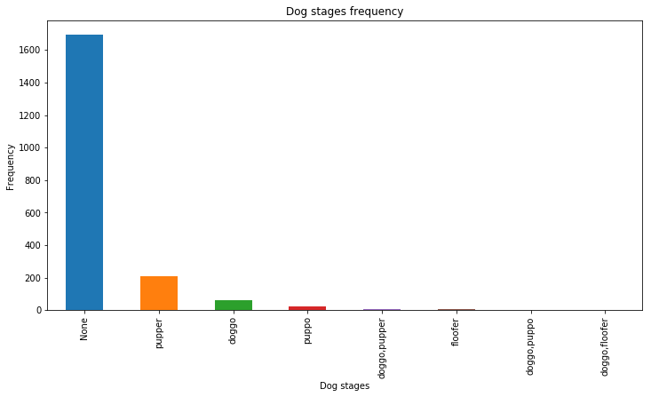

```python
# plot the graph
plt.figure(figsize = (12,6))
stages_count.plot(kind='bar')
plt.title('Dog stages frequency')
plt.xlabel('Dog stages')
plt.ylabel('Frequency')
```

### Does dog_stage has any influence on favorite_count and retweet_count?

```python
# remove nan from stages list
stages = df.dog_stage.unique()
stages = np.delete(stages, 0)
```

```python
# get favorite and retweet count for each stage in the stages list
favorite_count = []
retweet_count = []
for stage in stages:
    stage_df = df.query('dog_stage == @stage')
    favorite_proportion = sum(stage_df.favorite_count) / stages_count[stage]
    retweet_proportion = sum(stage_df.retweet_count) / stages_count[stage]
    favorite_count.append(favorite_proportion)
    retweet_count.append(retweet_proportion)
favorite_count, retweet_count
```

```
([20136.73015873016,
  16588.0,
  13047.555555555555,
  46243.0,
  12715.285714285714,
  6882.0,
  21856.363636363636],
 [7093.873015873016,
  3289.0,
  4014.777777777778,
  18306.0,
  4702.571428571428,
  2217.236714975845,
  6307.090909090909])
```

```
Text(0,0.5,'Favorite counts')
```

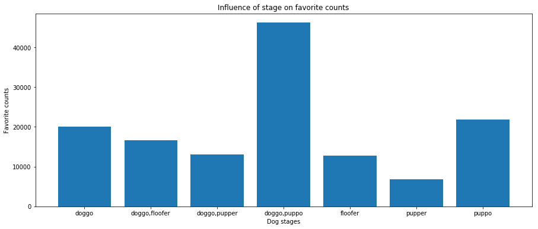

```python
# plot the graph
plt.figure(figsize = (15,6))
plt.bar(x=stages, height=favorite_count)
plt.title('Influence of stage on favorite counts')
plt.xlabel('Dog stages')
plt.ylabel('Favorite counts')
```

```
Text(0,0.5,'Retweet count')
```

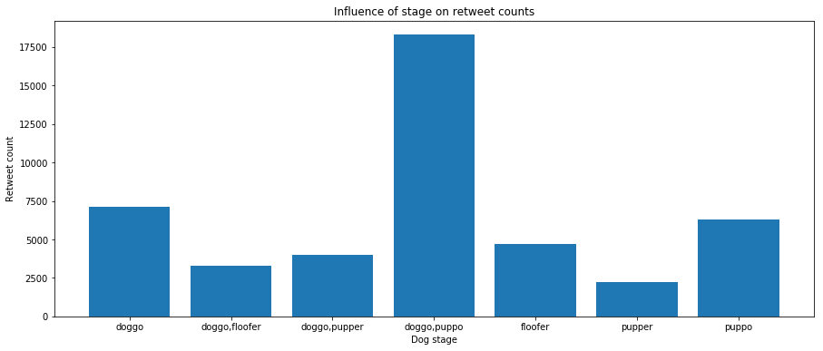

```python
plt.figure(figsize = (15,6))
plt.bar(x=stages, height=retweet_count)
plt.title('Influence of stage on retweet counts')
plt.xlabel('Dog stage')
plt.ylabel('Retweet count')
```

```
Text(0.5,0.98,'Correlation between favorite & retweet counts')
```

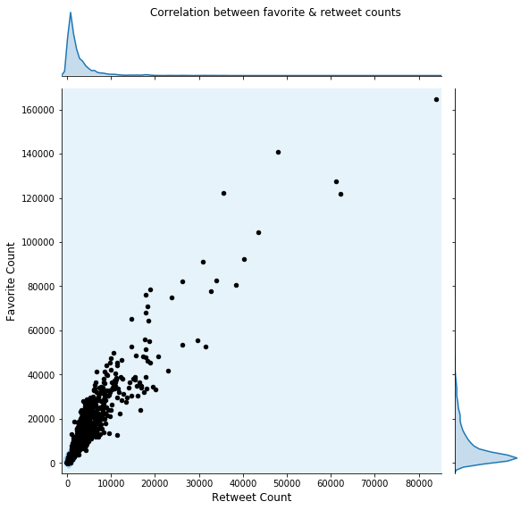

```python
# plot the relation between retweet and favorite counts
s = sns.jointplot(x="retweet_count", y="favorite_count", data=df, kind="kde", size=8)
s.plot_joint(plt.scatter, c="black", s=80, linewidth=1, marker=".")
s.set_axis_labels("Retweet Count", "Favorite Count",fontsize=12)
plt.suptitle('Correlation between favorite & retweet counts',fontsize=12)
```

```
Text(0,0.5,'Dog Names')
```

[figure not shown]

```python
#most common dog names
tweet_clean['name'].value_counts()[1:10].plot('barh')
plt.title('Most Common Dog Names (Top 10)')
plt.ylabel('Dog Names')

### Is there any correlation between favorite and retweet counts?
```

```
Text(0,0.5,'Number of Tweets')
```

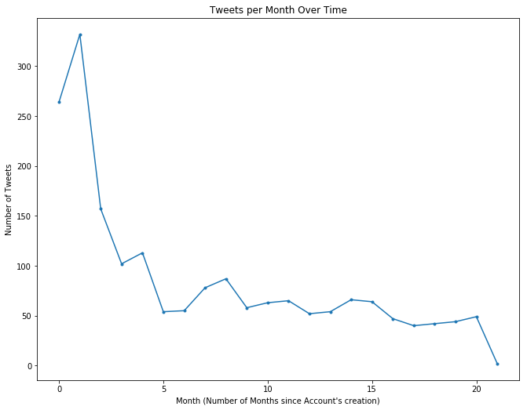

```python
nmonth = list(range(22))
smonth = ['11/2015', '12/2015', '1/2016', '2/2016', '3/2016', '4/2016', ]
tweets_per_month=[264, 332, 157, 102, 113, 54, 55, 78, 87, 58, 63, 65, 52, 54, 66, 64, 47, 40, 42, 44, 49, 2]
plt.figure(1, figsize = (11, 8.5))
plt.plot(nmonth, tweets_per_month, marker= 'o', ms=3)
plt.title('Tweets per Month Over Time')
plt.xlabel('Month (Number of Months since Account\'s creation)')
plt.ylabel('Number of Tweets')
```

The graph clearly illustrates that @dog_rates post rate has declined significantly since it’s creation. The slight dip at the end is less dramatic than it seems, since the data for August only includes the first of the month. The increase around 7.5 months corresponds with the summer months. Hinting the person running the twitter account was a student.

### Insights

- There exists a positive correlation between retweets and favorite counts.
- Among the 4 dog stages, pupper has the highest frequency.
- Besides pupper having the highest frequency, Puppo gets the highest number of favorite counts followed by doggo, floofer, pupper.
- Besides pupper having the highest frequency, Doggo gets the highest number of retweet counts followed by puppo, floofer, pupper.